# Multi-ancestry placental xQTL analysis

## 3.4 Signal fraction (Storey π1) per layer

Storey pi1 (estimated fraction of true associations) on permutation-calibrated p-values.

| layer | ancestry | modality | n | pi1 | min_q |
| --- | --- | --- | --- | --- | --- |
| combined | EAS | combined | 12589 | 0.313 | 0.000 |
| combined | EUR | combined | 13136 | 0.396 | 0.000 |
| grouped | EAS | RNA_editing | 353 | 0.382 | 0.000 |
| grouped | EAS | expression | 12565 | 0.273 | 0.000 |
| grouped | EAS | isoform_expression | 8478 | 0.259 | 0.000 |
| grouped | EAS | isoforms | 3028 | 0.196 | 0.000 |
| grouped | EAS | stability | 2928 | 0.170 | 0.000 |
| grouped | EAS | alt_polyA | 3055 | 0.147 | 0.000 |
| grouped | EAS | intron_retention | 1806 | 0.142 | 0.000 |
| grouped | EAS | alt_TSS | 3740 | 0.139 | 0.000 |
| grouped | EAS | splicing | 4911 | 0.095 | 0.002 |
| grouped | EUR | RNA_editing | 885 | 0.444 | 0.000 |
| grouped | EUR | isoform_expression | 10881 | 0.341 | 0.000 |
| grouped | EUR | expression | 13100 | 0.299 | 0.000 |
| grouped | EUR | splicing | 6940 | 0.272 | 0.000 |
| grouped | EUR | isoforms | 5479 | 0.244 | 0.000 |
| grouped | EUR | alt_polyA | 6319 | 0.204 | 0.000 |
| grouped | EUR | alt_TSS | 6356 | 0.197 | 0.000 |
| grouped | EUR | intron_retention | 2595 | 0.193 | 0.000 |
| grouped | EUR | stability | 6658 | 0.180 | 0.000 |
| ungrouped | EAS | isoform_expression | 12459 | 0.229 | 0.000 |
| ungrouped | EAS | isoforms | 4666 | 0.180 | 0.000 |
| ungrouped | EAS | stability | 2928 | 0.173 | 0.000 |
| ungrouped | EAS | RNA_editing | 3120 | 0.171 | 0.000 |
| ungrouped | EAS | alt_polyA | 6624 | 0.142 | 0.000 |
| ungrouped | EAS | alt_TSS | 9132 | 0.119 | 0.000 |
| ungrouped | EAS | intron_retention | 3808 | 0.107 | 0.000 |
| ungrouped | EAS | splicing | 20526 | 0.060 | 0.001 |
| ungrouped | EUR | isoform_expression | 20968 | 0.256 | 0.000 |
| ungrouped | EUR | RNA_editing | 17484 | 0.197 | 0.000 |
| ungrouped | EUR | isoforms | 10936 | 0.182 | 0.000 |
| ungrouped | EUR | stability | 6658 | 0.179 | 0.000 |
| ungrouped | EUR | alt_TSS | 20956 | 0.139 | 0.000 |
| ungrouped | EUR | alt_polyA | 21779 | 0.136 | 0.000 |
| ungrouped | EUR | intron_retention | 10295 | 0.123 | 0.000 |
| ungrouped | EUR | splicing | 31031 | 0.117 | 0.000 |

## 3.5 Power analysis

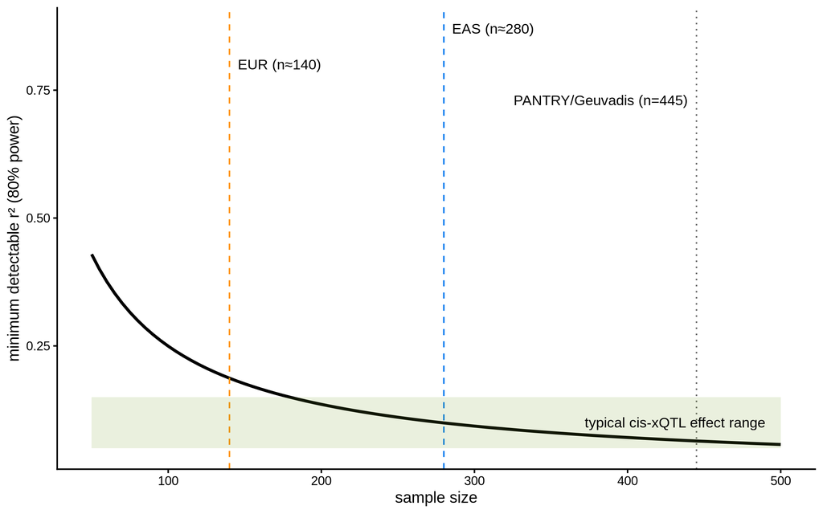

Minimum detectable effect (r², 80% power) at our sample sizes vs PANTRY’s n=445, per layer.

| ancestry | modality | n_tested | alpha | min_r2_our_n | min_r2_pantry_n |
| --- | --- | --- | --- | --- | --- |
| EAS | expression | 12565 | 0 | 0.099 | 0.064 |
| EAS | isoforms | 3028 | 0 | 0.089 | 0.057 |
| EAS | isoform_expression | 8478 | 0 | 0.097 | 0.062 |
| EAS | splicing | 4911 | 0 | 0.093 | 0.060 |
| EAS | intron_retention | 1806 | 0 | 0.085 | 0.055 |
| EAS | alt_TSS | 3740 | 0 | 0.091 | 0.058 |
| EAS | alt_polyA | 3055 | 0 | 0.089 | 0.057 |
| EAS | RNA_editing | 353 | 0 | 0.073 | 0.047 |
| EAS | stability | 2928 | 0 | 0.089 | 0.057 |
| EUR | expression | 13100 | 0 | 0.187 | 0.064 |
| EUR | isoforms | 5479 | 0 | 0.176 | 0.060 |
| EUR | isoform_expression | 10881 | 0 | 0.185 | 0.063 |
| EUR | splicing | 6940 | 0 | 0.179 | 0.061 |
| EUR | intron_retention | 2595 | 0 | 0.167 | 0.057 |
| EUR | alt_TSS | 6356 | 0 | 0.178 | 0.061 |
| EUR | alt_polyA | 6319 | 0 | 0.178 | 0.061 |
| EUR | RNA_editing | 885 | 0 | 0.152 | 0.051 |
| EUR | stability | 6658 | 0 | 0.179 | 0.061 |
| EAS | combined | 12589 | 0 | 0.099 | 0.064 |
| EUR | combined | 13136 | 0 | 0.187 | 0.064 |

## 3.6 Carrier-count audit: MAC floor propagation

Minimum minor-allele carrier counts per layer (mapping sample sets).

| ancestry | layer | min_carriers | n_lt5 | n_total |
| --- | --- | --- | --- | --- |
| EAS | combined | 6 | 0 | 12589 |
| EAS | grouped | 6 | 0 | 40864 |
| EAS | ungrouped | 6 | 0 | 63263 |
| EUR | combined | 3 | 2723 | 13136 |
| EUR | grouped | 3 | 11794 | 59213 |
| EUR | ungrouped | 3 | 28826 | 140107 |

The MAC ≥ 5 floor is applied at the genotype intersection in module 23 (before outlier exclusion). A fraction of tests retain < 5 carriers in the mapping sample sets (audit table) because the floor predates outlier exclusion and modality-specific sample attrition. No FDR-significant result should be carrier-limited; hit lists should be post-filtered to ma_count ≥ 5, and re-applying the floor after outlier exclusion would remove them at the source.

# 4 The landscape of placental xQTL regulation

*Modality-wise discovery landscape, following DevBrain Fig. 1. Two panels that manuscript draws from external datasets are adapted or omitted: eGene overlap and effect-size correlation against GTEx/PsychENCODE adult brain (1B/1C) have no external placenta xQTL resource — GTEx lacks placenta and the largest published placenta eQTL set (Peng 2017) is the RICHS cohort, already inside this atlas — and are omitted; discovery context is instead given against the published placenta eQTL literature (1A analog, below). Inversion QTLs (1J) are not assayed by this pipeline.*

## 4.1 Phenotypes and genes tested per modality

Genes tested per ancestry × modality (grouped layers).

| ancestry | modality | genes_tested |
| --- | --- | --- |
| EAS | RNA_editing | 353 |
| EAS | alt_TSS | 3740 |
| EAS | alt_polyA | 3055 |
| EAS | combined | 12589 |
| EAS | expression | 12565 |
| EAS | intron_retention | 1806 |
| EAS | isoform_expression | 8478 |
| EAS | isoforms | 3028 |
| EAS | splicing | 4911 |
| EAS | stability | 2928 |
| EUR | RNA_editing | 885 |
| EUR | alt_TSS | 6356 |
| EUR | alt_polyA | 6319 |
| EUR | combined | 13136 |
| EUR | expression | 13100 |
| EUR | intron_retention | 2595 |
| EUR | isoform_expression | 10881 |
| EUR | isoforms | 5479 |
| EUR | splicing | 6940 |
| EUR | stability | 6658 |

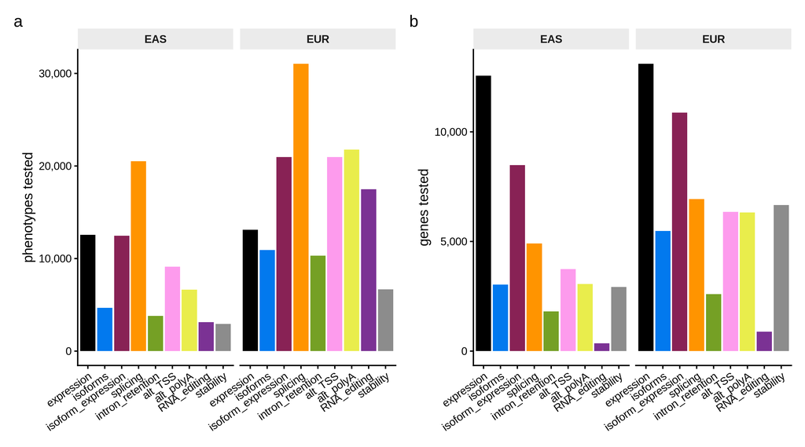

Note the ancestry asymmetry: EUR contributes roughly 1.5–5.6× more phenotypes than EAS in the ungrouped layer (ancestry-specific phenotype filtering; 1.5× for splicing up to 5.6× for RNA editing), while the gene universes are similar (~12–13k genes). Mapping sample sizes vary slightly by modality (EAS 271, EUR 134 across layers, inferred from allele-count/frequency denominators) because each modality’s phenotype matrix harmonizes to a slightly different sample set.

## 4.2 Discovery in the context of published placenta eQTL studies

*DevBrain Fig. 1A analog: eGene discovery versus sample size. Published values are hardcoded from the papers (captions/abstracts); note that Peng 2017 (RICHS) and Choi 2024 (SNUH) cohorts contribute to this atlas, so their points mark the ancestry-stratified predecessors of the present analysis rather than independent references.*

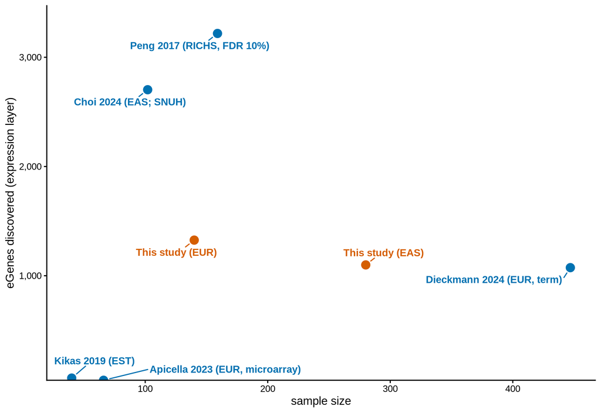

## 4.3 xQTL associations per modality — q-value tiers

*Discovery panel on the ungrouped (phenotype-level) layer — the fine-mapping input set — with expression contributed by its per-gene primary scan. DevBrain reports the analogous discovery counts per modality at FDR ≤ 5%.*

At FDR ≤ 5% the phenotype-level discovery layer contains **7328 associations** (2707 EAS, 4621 EUR) across 1667 / 2470 unique genes; the combined cross-modality layer adds 3495 gene-level eGenes. The figure shows the full q-value landscape: phenotypes binned by q-value per ancestry × modality. Splicing splits by ancestry: EUR splicing reaches the q ≤ 0.05 tier, while EAS splicing remains near-null — best q-value 8.1^{-4} — so the EAS splicing bar sits almost entirely in the q > 0.50 tier.

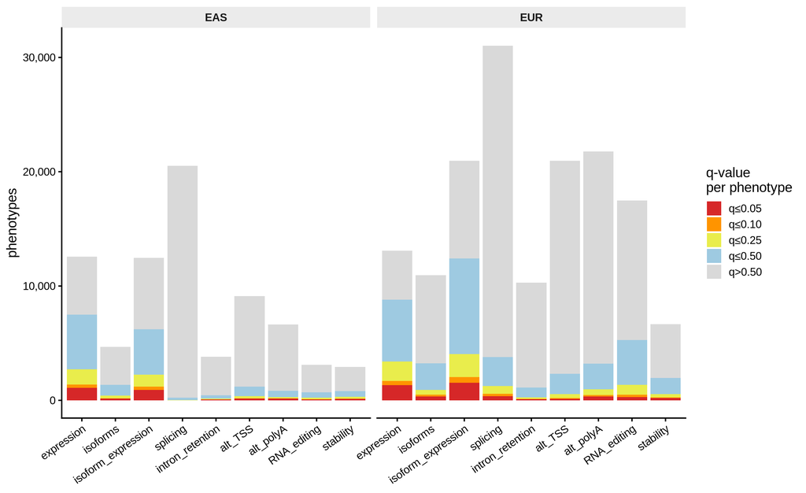

## 4.4 Conditionally independent signals per gene

*DevBrain Fig. 1H analog: the distribution of conditionally independent signals per tested unit, from the stepwise (`cis.map_independent`) scans — now run on the grouped, ungrouped, and combined layers alike.*

Stepwise regression (cis.map_independent) ran on 15,045 FDR-qualifying units across the three layers; 1,086 (7.2%) carry a conditionally independent secondary signal (rank ≥ 2).

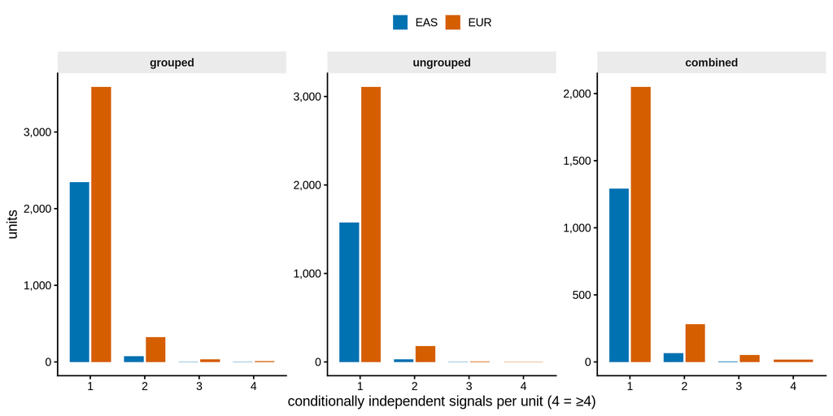

Units are gene groups in the grouped/combined layers and individual phenotypes in the ungrouped layer; only FDR ≤ 5% entrants undergo the stepwise scan. The design-level view below shows how many phenotypes each gene contributes to its group (the multiple-testing unit).

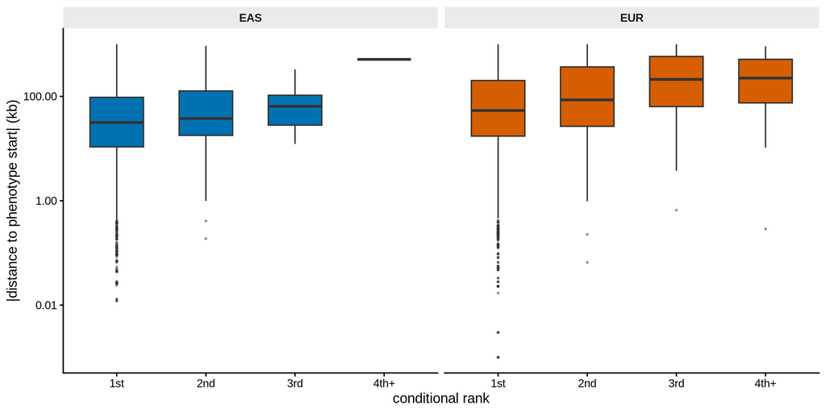

Primary (rank-1) signals are closer to the phenotype start than secondary signals (median 43.80 vs 82.73 kb; Wilcoxon p = 3.8e-29) — the allelic-heterogeneity pattern DevBrain reports (their fig. S3M/N).

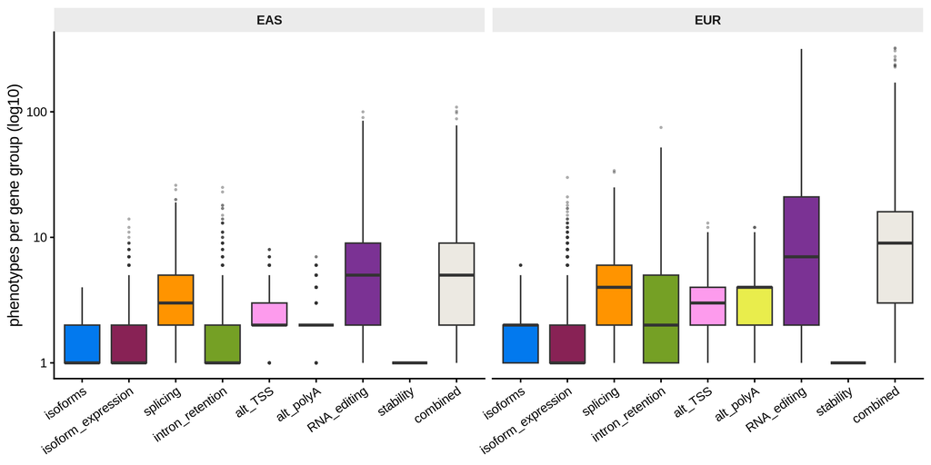

## 4.5 Lead-variant distance from the TSS

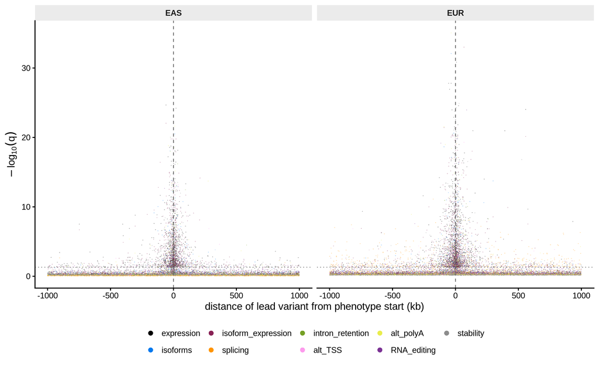

Every tested gene’s lead variant (grouped layers; non-significant bulk thinned to 1,500 points per modality for plotting). The vertical enrichment of points above the FDR ≤ 5% line near 0 kb is the expected TSS-proximal concentration of causal cis-regulatory variants.

## 4.6 Cross-modality overlap of xGenes

*DevBrain Fig. 1D analog: overlap among the modality-specific gene-level catalogs (grouped layers, FDR ≤ 5%), per ancestry.*

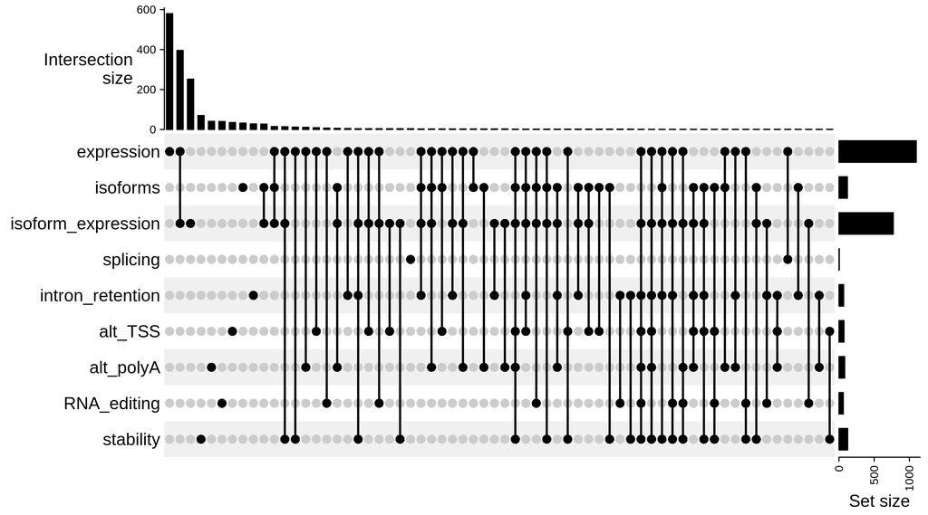

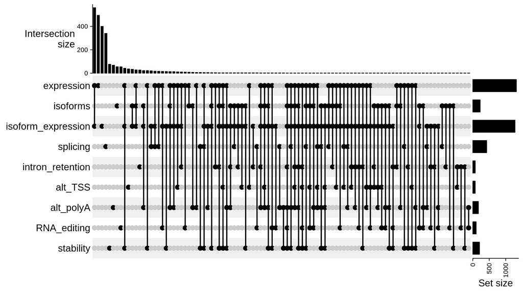

## 4.7 Functional annotation enrichment of lead variants

*DevBrain Fig. 1F analog: enrichment of fastVEP consequence classes and regulatory-element overlaps (ENCODE cCRE classes, placenta OCRs) among FDR ≤ 5% lead variants versus all tested lead variants — Fisher exact log2 odds ratios per ancestry × modality. Rendered only when lead_variant_annotations.tsv.gz is present in the archive (extraction script 35, with the fastVEP two-pass).*

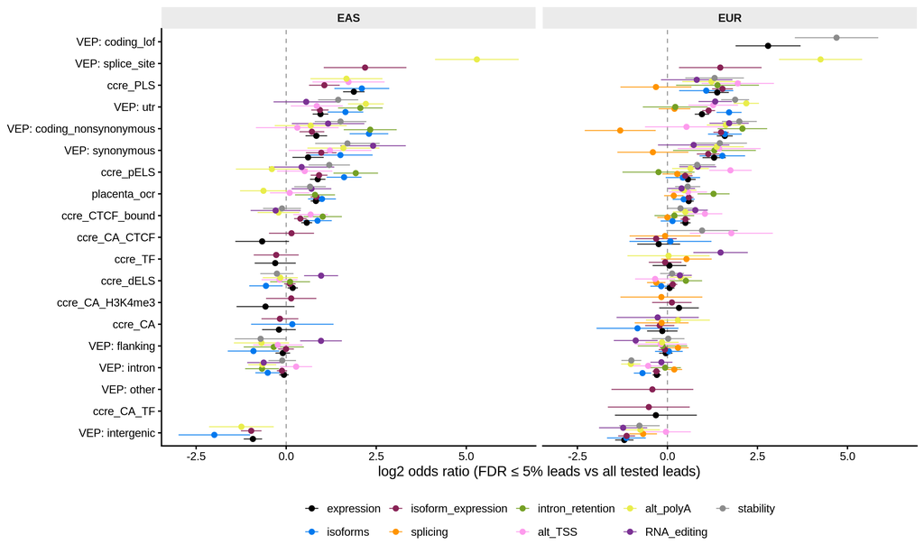

Positive log2OR = over-representation among significant leads; bars are Wald 95% CIs on the log odds ratio (cells with fewer than 3 annotated foreground variants, or fewer than 20 foreground variants per ancestry × modality cell, are omitted; p-values unadjusted). The expected cis-regulatory signature is enrichment of regulatory-region/cCRE/OCR classes and depletion of intergenic sequence.

## 4.8 Cross-modality sharing of xQTL effects

*DevBrain Fig. 1H analog: Storey π1 replication rate of each modality’s FDR ≤ 5% lead (variant, gene) pairs against the nominal association of the same variant across the gene’s phenotypes in every other grouped modality, per ancestry. Rendered only when cross_modality_lookup.tsv.gz is present.*

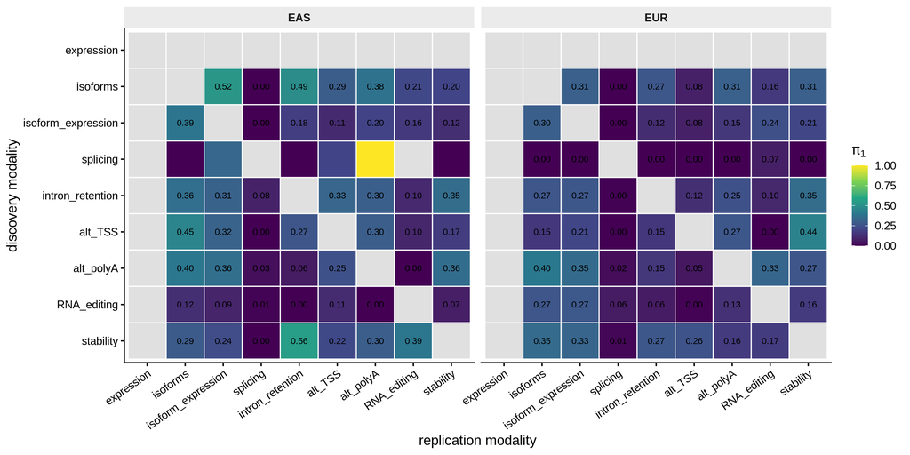

π1 = 1 − π0 (Storey, λ = 0.5) on replication-modality nominal p-values of each discovery modality’s FDR ≤ 5% leads; the diagonal (self-replication) is not computed and cells with fewer than 20 tested pairs are left blank. High off-diagonal π1 indicates that one modality’s regulatory variants recur as nominal associations in another — the cross-phenotype sharing the combined layer exploits.

## 4.9 Constraint of xGenes

*DevBrain Fig. 1G analog: gnomAD v2.1.1 loss-of-function constraint (LOEUF) of combined-layer eGenes, split by driver modality, versus tested non-eGenes. Rendered only when gene_constraint.tsv is present.*

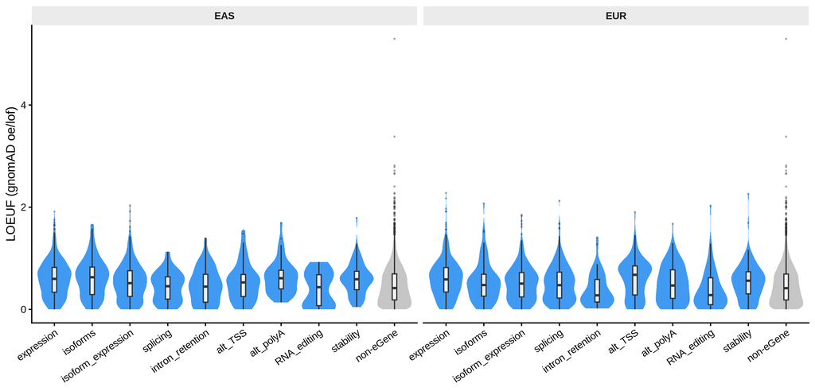

## 4.10 Fine-mapped credible sets versus conditional signals

*DevBrain Fig. 1I analog: the number of SuSHiE credible sets per locus versus the number of conditionally independent signals at the same phenotype (maximum rank across ancestries in the stepwise scans). Rendered only when the aggregated SuSHiE locus summary is present.*

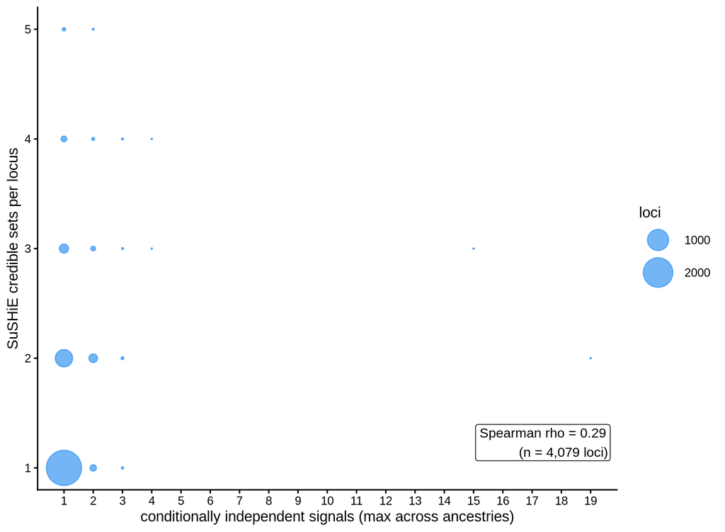

4,079 of 4,079 fine-mapped loci with credible sets matched a stepwise-conditional scan; the credible-set count tracks the conditional-signal count (Spearman rho = 0.29), cross-validating the two independence estimates.

# 5 Cross-ancestry regulation

*Following DevBrain Fig. 2: per-ancestry discovery (2B analog) and cross-ancestry effect-size concordance (2C analog). When the enriched archive is present (extraction script 35 + aggregated SuSHiE outputs), this section additionally renders the lead-slope replication scatter (2C), showcase-locus tracks (2E), and credible-set summaries (2D analog); without it those panels skip with a note and the gene-level hexbin is the fallback concordance view. Cross-ancestry analysis here is comparative only (no pooled p-value combination).*

## 5.1 Per-ancestry discovery comparison

Combined-layer eGene overlap between ancestries (genes tested in both: 12,450).

| set | n |
| --- | --- |
| EAS only | 730 |
| shared | 580 |
| EUR only | 1601 |

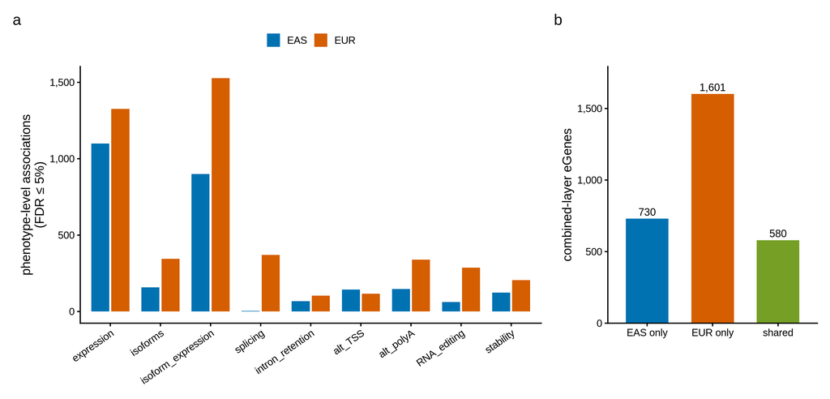

Of the 1310 EAS and 2181 EUR combined-layer eGenes, **580 are shared** (Fisher exact vs the tested-in-both universe: odds ratio 4.73, p = 7e-129) — shared eGenes are more frequent than expected under independence. The larger EUR discovery counts track its larger phenotype universe (ancestry-specific filtering; Landscape) rather than a larger mapping sample — EAS is the bigger stratum.

## 5.2 Ancestry-specific versus shared eGenes

*DevBrain fig. S4 analog (adapted): composition of the EAS-only, shared, and EUR-only combined-layer eGene sets — gene biotype (panel a) and, when the constraint table is present, gnomAD LOEUF (panel b).*

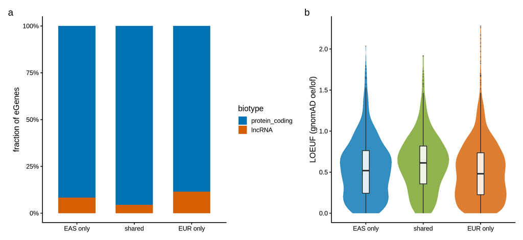

## 5.3 Cross-ancestry effect-size concordance

*DevBrain Fig. 2C analog: consistency of xQTL effects between the two ancestry strata. When the cross-ancestry lookup table is present this is shown as the DevBrain discovery-vs-replication lead-slope scatter; otherwise the gene-level −log10(p) hexbin below is the fallback view.*

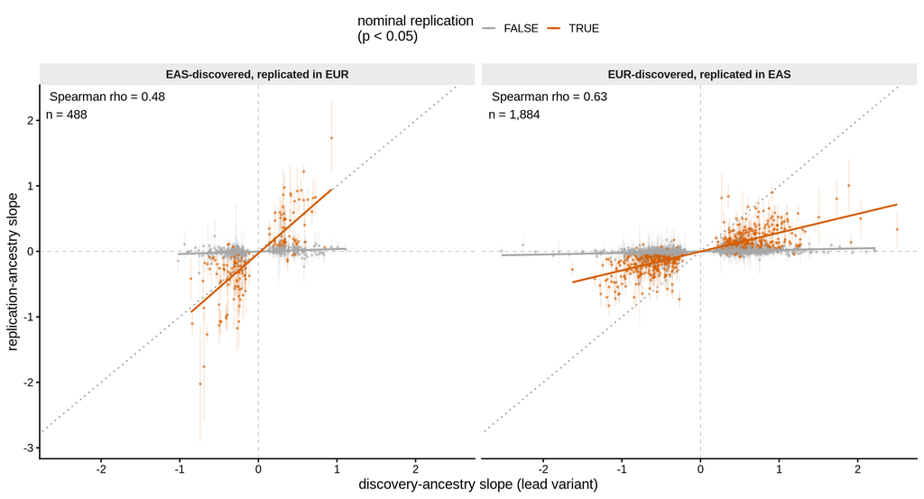

Each point is an FDR ≤ 5% discovery-layer lead (variant, phenotype) pair; the y-axis is the same pair’s slope in the other ancestry from a targeted lookup (bars: ±1.96·SE). Slopes are on inverse-normal-transformed phenotypes — both strata share the transform, so slopes (not aFC) are the comparable effect scale here, a deliberate deviation from DevBrain’s aFC panel. Of 2,372 looked-up pairs, 813 (34.3%) replicate at nominal p < 0.05 and direction agrees in 77.3%.

Cross-ancestry concordance per layer: genes tested in both ancestries, same-lead-variant count, Spearman correlation of -log10(pval_beta), and top-100 gene overlap.

| modality | n_genes | same_variant | rank_spearman | top100_overlap |
| --- | --- | --- | --- | --- |
| expression | 12415 | 47 | 0.178 | 25 |
| isoforms | 3020 | 5 | 0.087 | 36 |
| isoform_expression | 8449 | 21 | 0.185 | 32 |
| splicing | 4707 | 0 | -0.004 | 5 |
| intron_retention | 1444 | 2 | 0.057 | 25 |
| alt_TSS | 3727 | 2 | 0.037 | 13 |
| alt_polyA | 3048 | 3 | 0.092 | 27 |
| RNA_editing | 352 | 1 | 0.252 | 49 |
| stability | 2925 | 4 | 0.064 | 23 |
| combined | 12450 | 34 | 0.164 | 26 |

## 5.4 Showcase loci

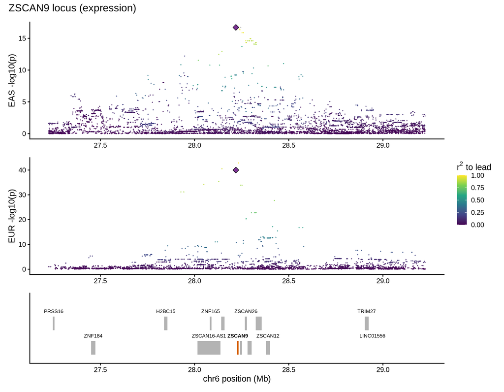

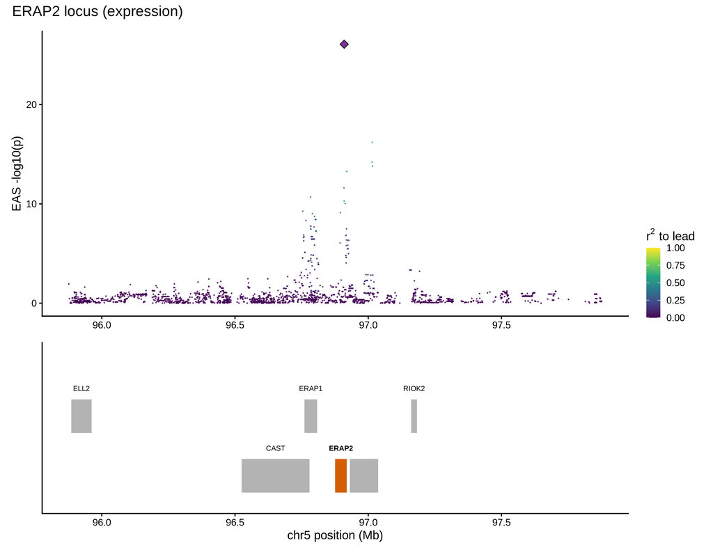

The lead variant (purple diamond) sits in a TSS-proximal LD block; ancestry differences in the tracks reflect both LD structure and true effect heterogeneity, which the joint SuSHiE fine-mapping quantifies formally.

## 5.5 SuSHiE credible-set summary

*DevBrain Fig. 2D analog (conditional): size distribution of purity-pruned credible sets and the cross-ancestry effect-correlation estimates, from the aggregated SuSHiE outputs. Rendered only when finemap_credible_sets.tsv.gz is present; per-locus detail remains in report_finemap.*

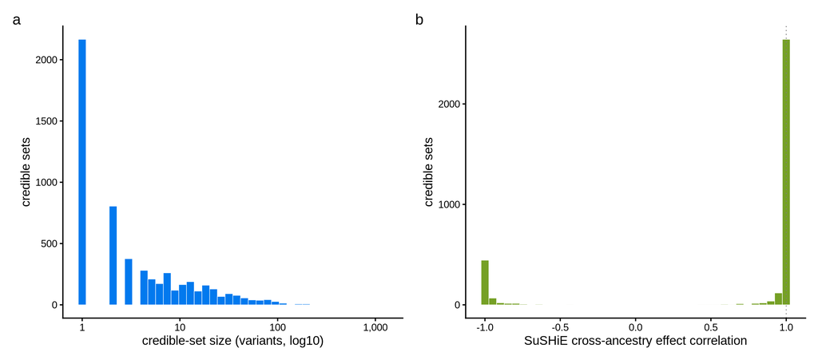

# 6 Discovery catalog

## 6.1 FDR-significant associations

FDR ≤ 5% associations across layers (top 100 of 14,680 shown; full table in tables/fdr_hits.tsv). Grouped/combined rows are gene-level; ungrouped rows are phenotype-level.

| ancestry | layer | modality_display | gene_id | gene_symbol | phenotype_id | target | variant_id | af | ma_count | slope | pval_nominal | pval_beta | qval | variant_to_target_kb |
| --- | --- | --- | --- | --- | --- | --- | --- | --- | --- | --- | --- | --- | --- | --- |
| EAS | combined | combined (driver: expression) | ENSG00000079739 | PGM1 | expression__ENSG00000079739.17 |  | 1:63616853:A:G | 0.130 | 72 | -0.909 | 0 | 0 | 0 | 23 |
| EAS | combined | combined (driver: expression) | ENSG00000290199 | ENSG00000290199 | expression__ENSG00000290199.1 |  | 22:23915150:G:A | 0.447 | 249 | 0.923 | 0 | 0 | 0 | 59 |
| EAS | combined | combined (driver: alt_polyA) | ENSG00000167653 | PSCA | alt_polyA__ENSG00000167653.5__grp_2_downstream_ENST00000301258.5 | grp_2_downstream_ENST00000301258.5 | 8:142680513:C:T | 0.406 | 226 | 0.728 | 0 | 0 | 0 | 10 |
| EAS | combined | combined (driver: isoform_expression) | ENSG00000077942 | FBLN1 | isoform_expression__ENSG00000077942.19__HPLRT_ba7f4185a16 | HPLRT_ba7f4185a16 | 22:45483551:C:T | 0.556 | 247 | 0.676 | 0 | 0 | 0 | 19 |
| EAS | combined | combined (driver: expression) | ENSG00000114473 | IQCG | expression__ENSG00000114473.14 |  | 3:197962641:A:G | 0.043 | 24 | 1.338 | 0 | 0 | 0 | 2 |
| EAS | combined | combined (driver: expression) | ENSG00000164308 | ERAP2 | expression__ENSG00000164308.17 |  | 5:96909814:A:G | 0.547 | 253 | -0.685 | 0 | 0 | 0 | 34 |
| EAS | combined | combined (driver: expression) | ENSG00000144115 | THNSL2 | expression__ENSG00000144115.18 |  | 2:88170251:G:C | 0.774 | 126 | 0.708 | 0 | 0 | 0 | 0 |
| EAS | combined | combined (driver: expression) | ENSG00000233927 | RPS28 | expression__ENSG00000233927.5 |  | 19:8333647:T:C | 0.452 | 252 | -0.685 | 0 | 0 | 0 | 12 |
| EAS | combined | combined (driver: expression) | ENSG00000111671 | SPSB2 | expression__ENSG00000111671.10 |  | 12:6869539:G:C | 0.240 | 130 | 0.555 | 0 | 0 | 0 | 20 |
| EAS | combined | combined (driver: isoform_expression) | ENSG00000143337 | TOR1AIP1 | isoform_expression__ENSG00000143337.19__ENST00000528443.6 | ENST00000528443.6 | 1:179855458:T:A | 0.253 | 141 | 0.981 | 0 | 0 | 0 | 27 |
| EAS | combined | combined (driver: expression) | ENSG00000106066 | CPVL | expression__ENSG00000106066.15 |  | 7:29153130:A:G | 0.358 | 200 | -0.467 | 0 | 0 | 0 | 42 |
| EAS | combined | combined (driver: intron_retention) | ENSG00000055950 | MRPL43 | intron_retention__ENSG00000055950.17__IR_ENSG00000055950_chr10_100986573_100986587_-_14340 | IR_ENSG00000055950_chr10_100986573_100986587_-_14340 | 10:100991949:G:A | 0.527 | 263 | -0.658 | 0 | 0 | 0 | 4 |
| EAS | combined | combined (driver: alt_polyA) | ENSG00000170291 | ELP5 | alt_polyA__ENSG00000170291.16__grp_2_downstream_ENST00000574255.6 | grp_2_downstream_ENST00000574255.6 | 17:7254027:G:GAGAACC | 0.650 | 195 | -0.725 | 0 | 0 | 0 | 3 |
| EAS | combined | combined (driver: isoform_expression) | ENSG00000166435 | XRRA1 | isoform_expression__ENSG00000166435.17__ENST00000531449.5 | ENST00000531449.5 | 11:74844011:C:T | 0.578 | 235 | 0.716 | 0 | 0 | 0 | 105 |
| EAS | combined | combined (driver: isoforms) | ENSG00000105750 | ZNF85 | isoforms__ENSG00000105750.15__ENST00000300540.7 | ENST00000300540.7 | 19:20922291:A:G | 0.476 | 265 | 0.640 | 0 | 0 | 0 | 1 |
| EAS | combined | combined (driver: alt_TSS) | ENSG00000138398 | PPIG | alt_TSS__ENSG00000138398.17__grp_1_upstream_ENST00000676756.1 | grp_1_upstream_ENST00000676756.1 | 2:169577357:A:G | 0.199 | 109 | 0.935 | 0 | 0 | 0 | 7 |
| EAS | combined | combined (driver: expression) | ENSG00000119535 | CSF3R | expression__ENSG00000119535.20 |  | 1:36495025:G:A | 0.505 | 275 | 0.519 | 0 | 0 | 0 | 12 |
| EAS | combined | combined (driver: isoform_expression) | ENSG00000100376 | FAM118A | isoform_expression__ENSG00000100376.12__ENST00000441876.7 | ENST00000441876.7 | 22:45327703:G:A | 0.790 | 117 | -0.736 | 0 | 0 | 0 | 19 |
| EAS | combined | combined (driver: alt_polyA) | ENSG00000089127 | OAS1 | alt_polyA__ENSG00000089127.15__grp_2_downstream_ENST00000202917.10 | grp_2_downstream_ENST00000202917.10 | 12:112919388:G:A | 0.746 | 142 | -0.830 | 0 | 0 | 0 | 14 |
| EAS | combined | combined (driver: RNA_editing) | ENSG00000129925 | PGAP6 | RNA_editing__ENSG00000129925.11__chr16_377516 | chr16_377516 | 16:377657:G:A | 0.308 | 171 | 0.894 | 0 | 0 | 0 | 0 |
| EAS | combined | combined (driver: expression) | ENSG00000112303 | VNN2 | expression__ENSG00000112303.14 |  | 6:132733307:C:T | 0.306 | 170 | -0.695 | 0 | 0 | 0 | 30 |
| EAS | combined | combined (driver: isoform_expression) | ENSG00000129493 | HEATR5A | isoform_expression__ENSG00000129493.15__HPLRT_85f4903f168 | HPLRT_85f4903f168 | 14:31389003:C:T | 0.333 | 185 | 0.717 | 0 | 0 | 0 | 32 |
| EAS | combined | combined (driver: expression) | ENSG00000080007 | DDX43 | expression__ENSG00000080007.8 |  | 6:73394696:A:C | 0.162 | 90 | -0.748 | 0 | 0 | 0 | 0 |
| EAS | combined | combined (driver: expression) | ENSG00000178301 | AQP11 | expression__ENSG00000178301.4 |  | 11:77555618:T:G | 0.281 | 156 | 0.652 | 0 | 0 | 0 | 34 |
| EAS | combined | combined (driver: isoforms) | ENSG00000165055 | METTL2B | isoforms__ENSG00000165055.16__ENST00000262432.13 | ENST00000262432.13 | 7:128477173:G:A | 0.296 | 164 | -0.862 | 0 | 0 | 0 | 0 |
| EAS | combined | combined (driver: alt_polyA) | ENSG00000132199 | ENOSF1 | alt_polyA__ENSG00000132199.20__grp_2_downstream_ENST00000582745.5 | grp_2_downstream_ENST00000582745.5 | 18:673086:A:G | 0.384 | 214 | 0.421 | 0 | 0 | 0 | 40 |
| EAS | combined | combined (driver: RNA_editing) | ENSG00000135679 | MDM2 | RNA_editing__ENSG00000135679.27__chr12_68839435 | chr12_68839435 | 12:68800623:A:G | 0.028 | 15 | 1.829 | 0 | 0 | 0 | 39 |
| EAS | combined | combined (driver: RNA_editing) | ENSG00000135046 | ANXA1 | RNA_editing__ENSG00000135046.14__chr9_73160319 | chr9_73160319 | 9:73160319:A:G | 0.193 | 107 | 0.900 | 0 | 0 | 0 | 0 |
| EAS | combined | combined (driver: expression) | ENSG00000183876 | ARSI | expression__ENSG00000183876.9 |  | 5:150323238:C:G | 0.251 | 140 | 0.557 | 0 | 0 | 0 | 16 |
| EAS | combined | combined (driver: RNA_editing) | ENSG00000184009 | ACTG1 | RNA_editing__ENSG00000184009.13__chr17_81510406 | chr17_81510406 | 17:81507326:G:A | 0.032 | 17 | 1.539 | 0 | 0 | 0 | 3 |

[output cut: 70 more lines]

Per-gene context tables show each FDR-significant gene across all layers and both ancestries (grouped/combined rows are gene-level; ungrouped rows are phenotype-level leads). Read the pattern per gene: a hit confined to one layer and one ancestry is ancestry- and modality-specific; a hit that also passes in the combined layer survives the cross-modality grouping burden.

#### 6.1.0.1 EAS — CFH

CFH (ENSG00000000971) across layers and ancestries.

| ancestry | modality | layer | variant_id | af | ma_count | pval_beta | qval |
| --- | --- | --- | --- | --- | --- | --- | --- |
| EAS | expression | grouped | 1:196428689:G:A | 0.613 | 216 | 0.003 | 0.024 |
| EAS | isoform_expression | combined | 1:196428689:G:A | 0.613 | 215 | 0.006 | 0.034 |
| EAS | isoform_expression | ungrouped | 1:196431123:C:T | 0.321 | 179 | 0.028 | 0.153 |
| EAS | isoform_expression | grouped | 1:196431123:C:T | 0.321 | 179 | 0.053 | 0.190 |
| EAS | isoform_expression | ungrouped | 1:196682702:T:C | 0.085 | 47 | 0.219 | 0.420 |
| EAS | alt_polyA | grouped | 1:195960271:C:CA | 0.545 | 254 | 0.389 | 0.632 |
| EAS | alt_polyA | ungrouped | 1:195960271:C:CA | 0.545 | 254 | 0.263 | 0.658 |
| EAS | intron_retention | grouped | 1:196672942:C:T | 0.403 | 225 | 0.651 | 0.672 |
| EAS | alt_polyA | ungrouped | 1:195960271:C:CA | 0.545 | 254 | 0.404 | 0.711 |
| EAS | intron_retention | ungrouped | 1:196672942:C:T | 0.403 | 225 | 0.649 | 0.721 |
| EAS | alt_polyA | ungrouped | 1:197332557:A:C | 0.050 | 27 | 0.749 | 0.799 |
| EAS | alt_polyA | ungrouped | 1:197332557:A:C | 0.050 | 27 | 0.769 | 0.803 |
| EAS | splicing | grouped | 1:196437945:C:T | 0.313 | 174 | 0.511 | 0.819 |
| EAS | splicing | ungrouped | 1:196437945:C:T | 0.313 | 174 | 0.438 | 0.886 |
| EAS | splicing | ungrouped | 1:196437945:C:T | 0.313 | 174 | 0.470 | 0.893 |
| EUR | isoforms | grouped | 1:196462026:C:A | 0.086 | 24 | 0.027 | 0.181 |
| EUR | isoforms | ungrouped | 1:196462026:C:A | 0.086 | 24 | 0.018 | 0.191 |
| EUR | isoform_expression | ungrouped | 1:196727803:G:A | 0.403 | 112 | 0.122 | 0.307 |
| EUR | isoform_expression | grouped | 1:196727803:G:A | 0.403 | 112 | 0.312 | 0.329 |
| EUR | isoforms | ungrouped | 1:196462026:C:A | 0.086 | 24 | 0.058 | 0.333 |
| EUR | splicing | combined | 1:196412047:C:T | 0.011 | 3 | 0.561 | 0.340 |
| EUR | expression | grouped | 1:196677131:A:G | 0.618 | 107 | 0.305 | 0.408 |
| EUR | alt_polyA | grouped | 1:196907304:A:C | 0.014 | 4 | 0.187 | 0.442 |
| EUR | splicing | grouped | 1:196246779:C:A | 0.091 | 25 | 0.320 | 0.458 |
| EUR | isoform_expression | ungrouped | 1:196272374:C:A | 0.050 | 14 | 0.576 | 0.539 |
| EUR | alt_polyA | ungrouped | 1:196907304:A:C | 0.014 | 4 | 0.129 | 0.552 |
| EUR | alt_polyA | ungrouped | 1:196907304:A:C | 0.014 | 4 | 0.137 | 0.563 |
| EUR | splicing | ungrouped | 1:196246779:C:A | 0.091 | 25 | 0.110 | 0.563 |
| EUR | isoform_expression | ungrouped | 1:197627375:C:T | 0.150 | 40 | 0.706 | 0.575 |
| EUR | alt_polyA | ungrouped | 1:196907304:A:C | 0.014 | 4 | 0.186 | 0.609 |
| EUR | alt_polyA | ungrouped | 1:196907304:A:C | 0.014 | 4 | 0.209 | 0.624 |
| EUR | splicing | ungrouped | 1:197567944:G:C | 0.015 | 4 | 0.269 | 0.699 |
| EUR | splicing | ungrouped | 1:197613650:A:G | 0.325 | 89 | 0.536 | 0.797 |
| EUR | splicing | ungrouped | 1:197613650:A:G | 0.325 | 89 | 0.562 | 0.804 |
| EUR | splicing | ungrouped | 1:196246779:C:A | 0.091 | 25 | 0.577 | 0.806 |

#### 6.1.0.2 EAS — SEMA3F

SEMA3F (ENSG00000001617) across layers and ancestries.

| ancestry | modality | layer | variant_id | af | ma_count | pval_beta | qval |
| --- | --- | --- | --- | --- | --- | --- | --- |
| EAS | isoform_expression | grouped | 3:50362575:T:C | 0.027 | 15 | 0.000 | 0.000 |
| EAS | isoform_expression | ungrouped | 3:50362575:T:C | 0.027 | 15 | 0.000 | 0.000 |
| EAS | isoform_expression | combined | 3:50143180:A:G | 0.031 | 17 | 0.000 | 0.000 |
| EAS | expression | grouped | 3:50143180:A:G | 0.031 | 17 | 0.000 | 0.000 |
| EUR | isoform_expression | grouped | 3:50186792:A:G | 0.615 | 107 | 0.000 | 0.000 |
| EUR | isoform_expression | ungrouped | 3:50186792:A:G | 0.615 | 107 | 0.000 | 0.000 |
| EUR | expression | grouped | 3:50186792:A:G | 0.615 | 107 | 0.000 | 0.001 |
| EUR | expression | combined | 3:50186792:A:G | 0.613 | 106 | 0.002 | 0.008 |
| EUR | stability | ungrouped | 3:50560616:T:G | 0.150 | 40 | 0.059 | 0.336 |
| EUR | stability | grouped | 3:50560616:T:G | 0.150 | 40 | 0.060 | 0.344 |

#### 6.1.0.3 EAS — AOC1

AOC1 (ENSG00000002726) across layers and ancestries.

| ancestry | modality | layer | variant_id | af | ma_count | pval_beta | qval |
| --- | --- | --- | --- | --- | --- | --- | --- |
| EAS | isoform_expression | ungrouped | 7:150860534:G:A | 0.500 | 280 | 0.000 | 0.000 |
| EAS | isoform_expression | grouped | 7:150860534:G:A | 0.500 | 280 | 0.000 | 0.000 |
| EAS | isoform_expression | combined | 7:150861311:G:A | 0.462 | 257 | 0.000 | 0.000 |
| EAS | isoform_expression | ungrouped | 7:150830474:A:C | 0.103 | 55 | 0.002 | 0.019 |
| EAS | isoform_expression | ungrouped | 7:150830474:A:C | 0.103 | 55 | 0.002 | 0.025 |
| EAS | expression | grouped | 7:150830813:T:C | 0.082 | 44 | 0.011 | 0.072 |
| EAS | isoform_expression | ungrouped | 7:150378067:T:C | 0.025 | 14 | 0.165 | 0.376 |
| EAS | alt_polyA | ungrouped | 7:150348213:G:A | 0.261 | 146 | 0.111 | 0.542 |
| EAS | alt_polyA | ungrouped | 7:151726259:G:A | 0.897 | 57 | 0.120 | 0.549 |
| EAS | alt_polyA | grouped | 7:150348213:G:A | 0.261 | 146 | 0.204 | 0.561 |
| EAS | splicing | grouped | 7:151109239:T:TA | 0.138 | 75 | 0.856 | 0.875 |
| EAS | splicing | ungrouped | 7:151109239:T:TA | 0.138 | 75 | 0.854 | 0.937 |
| EUR | alt_polyA | ungrouped | 7:150858827:A:G | 0.309 | 86 | 0.000 | 0.000 |
| EUR | alt_polyA | grouped | 7:150858827:A:G | 0.309 | 86 | 0.000 | 0.000 |
| EUR | alt_polyA | combined | 7:150858827:A:G | 0.310 | 85 | 0.000 | 0.000 |
| EUR | isoform_expression | ungrouped | 7:150860534:G:A | 0.304 | 85 | 0.000 | 0.000 |
| EUR | isoform_expression | grouped | 7:150860534:G:A | 0.304 | 85 | 0.000 | 0.000 |
| EUR | alt_polyA | ungrouped | 7:150858827:A:G | 0.309 | 86 | 0.000 | 0.000 |
| EUR | expression | grouped | 7:150836677:C:A | 0.463 | 129 | 0.000 | 0.000 |
| EUR | alt_TSS | ungrouped | 7:150860534:G:A | 0.304 | 85 | 0.000 | 0.000 |
| EUR | alt_TSS | grouped | 7:150860534:G:A | 0.304 | 85 | 0.000 | 0.000 |
| EUR | alt_TSS | ungrouped | 7:150860534:G:A | 0.304 | 85 | 0.000 | 0.000 |
| EUR | isoform_expression | ungrouped | 7:150845558:G:A | 0.544 | 127 | 0.000 | 0.001 |
| EUR | splicing | grouped | 7:150043839:A:C | 0.030 | 8 | 0.000 | 0.006 |
| EUR | splicing | ungrouped | 7:150043839:A:C | 0.030 | 8 | 0.000 | 0.021 |
| EUR | isoform_expression | ungrouped | 7:150845558:G:A | 0.544 | 127 | 0.002 | 0.024 |
| EUR | isoform_expression | ungrouped | 7:150858827:A:G | 0.309 | 86 | 0.007 | 0.062 |
| EUR | isoform_expression | ungrouped | 7:150860534:G:A | 0.304 | 85 | 0.011 | 0.083 |
| EUR | isoforms | ungrouped | 7:151218668:C:G | 0.014 | 4 | 0.005 | 0.090 |
| EUR | isoforms | grouped | 7:151218668:C:G | 0.014 | 4 | 0.015 | 0.134 |
| EUR | isoforms | ungrouped | 7:150386714:A:G | 0.018 | 5 | 0.154 | 0.459 |
| EUR | alt_polyA | ungrouped | 7:151684286:G:A | 0.011 | 3 | 0.081 | 0.489 |
| EUR | alt_TSS | ungrouped | 7:150958555:G:A | 0.339 | 95 | 0.170 | 0.599 |
| EUR | isoforms | ungrouped | 7:150615967:T:G | 0.216 | 58 | 0.466 | 0.606 |
| EUR | alt_polyA | ungrouped | 7:150766506:G:A | 0.019 | 5 | 0.182 | 0.607 |
| EUR | alt_TSS | ungrouped | 7:150958555:G:A | 0.339 | 95 | 0.236 | 0.638 |

#### 6.1.0.4 EAS — TMEM176A

TMEM176A (ENSG00000002933) across layers and ancestries.

| ancestry | modality | layer | variant_id | af | ma_count | pval_beta | qval |
| --- | --- | --- | --- | --- | --- | --- | --- |
| EAS | isoform_expression | combined | 7:150803446:G:A | 0.034 | 19 | 0.001 | 0.007 |
| EAS | expression | grouped | 7:150866220:C:T | 0.086 | 46 | 0.002 | 0.019 |
| EAS | isoform_expression | ungrouped | 7:150803446:G:A | 0.034 | 19 | 0.027 | 0.150 |
| EAS | isoform_expression | grouped | 7:150803446:G:A | 0.034 | 19 | 0.054 | 0.191 |
| EAS | isoform_expression | ungrouped | 7:151146163:A:G | 0.013 | 7 | 0.728 | 0.621 |
| EAS | alt_TSS | ungrouped | 7:151735547:T:C | 0.439 | 246 | 0.230 | 0.643 |
| EAS | alt_TSS | grouped | 7:151735547:T:C | 0.439 | 246 | 0.397 | 0.643 |
| EAS | isoforms | grouped | 7:151550628:A:G | 0.311 | 174 | 0.673 | 0.665 |
| EAS | alt_TSS | ungrouped | 7:150804157:C:T | 0.125 | 70 | 0.276 | 0.672 |
| EAS | isoforms | ungrouped | 7:151550628:A:G | 0.311 | 174 | 0.676 | 0.688 |
| EAS | intron_retention | grouped | 7:151555997:C:A | 0.669 | 185 | 0.820 | 0.703 |
| EAS | intron_retention | ungrouped | 7:151555997:C:A | 0.669 | 185 | 0.817 | 0.747 |
| EAS | splicing | grouped | 7:151390673:A:C | 0.026 | 14 | 0.493 | 0.814 |
| EAS | splicing | ungrouped | 7:151390673:A:C | 0.026 | 14 | 0.163 | 0.838 |
| EAS | splicing | ungrouped | 7:151390673:A:C | 0.026 | 14 | 0.195 | 0.847 |
| EAS | splicing | ungrouped | 7:151069651:T:C | 0.951 | 27 | 0.476 | 0.893 |
| EAS | splicing | ungrouped | 7:151394716:C:T | 0.017 | 9 | 0.677 | 0.918 |
| EAS | splicing | ungrouped | 7:150511883:T:C | 0.145 | 80 | 0.887 | 0.942 |
| EUR | splicing | grouped | 7:150043839:A:C | 0.030 | 8 | 0.002 | 0.028 |
| EUR | splicing | ungrouped | 7:150043839:A:C | 0.030 | 8 | 0.000 | 0.038 |
| EUR | expression | grouped | 7:151155385:T:C | 0.019 | 5 | 0.008 | 0.049 |
| EUR | alt_TSS | combined | 7:149802238:C:T | 0.019 | 5 | 0.197 | 0.210 |
| EUR | splicing | ungrouped | 7:149871215:C:T | 0.015 | 4 | 0.019 | 0.311 |
| EUR | isoform_expression | grouped | 7:151103514:G:A | 0.022 | 6 | 0.512 | 0.397 |
| EUR | alt_TSS | grouped | 7:149802238:C:T | 0.019 | 5 | 0.129 | 0.425 |
| EUR | alt_TSS | ungrouped | 7:149802238:C:T | 0.019 | 5 | 0.038 | 0.432 |
| EUR | isoform_expression | ungrouped | 7:151103514:G:A | 0.022 | 6 | 0.310 | 0.435 |
| EUR | isoform_expression | ungrouped | 7:150978822:A:G | 0.920 | 22 | 0.406 | 0.478 |
| EUR | isoforms | grouped | 7:150857799:G:A | 0.200 | 54 | 0.364 | 0.483 |
| EUR | alt_TSS | ungrouped | 7:149802238:C:T | 0.019 | 5 | 0.071 | 0.505 |
| EUR | isoforms | ungrouped | 7:150857799:G:A | 0.200 | 54 | 0.217 | 0.510 |
| EUR | isoforms | ungrouped | 7:150515546:C:A | 0.133 | 37 | 0.462 | 0.605 |
| EUR | alt_TSS | ungrouped | 7:150815740:A:C | 0.209 | 56 | 0.195 | 0.615 |
| EUR | splicing | ungrouped | 7:150807752:T:C | 0.293 | 80 | 0.448 | 0.772 |
| EUR | splicing | ungrouped | 7:150811427:C:A | 0.200 | 54 | 0.575 | 0.806 |
| EUR | alt_TSS | ungrouped | 7:151355957:A:G | 0.713 | 80 | 0.838 | 0.808 |
| EUR | splicing | ungrouped | 7:151069712:A:G | 0.599 | 110 | 0.693 | 0.833 |

#### 6.1.0.5 EAS — M6PR

M6PR (ENSG00000003056) across layers and ancestries.

| ancestry | modality | layer | variant_id | af | ma_count | pval_beta | qval |
| --- | --- | --- | --- | --- | --- | --- | --- |
| EAS | expression | grouped | 12:8946399:G:GAAC | 0.306 | 171 | 0.000 | 0.005 |
| EAS | isoform_expression | combined | 12:8946399:G:GAAC | 0.307 | 171 | 0.011 | 0.056 |
| EAS | isoform_expression | ungrouped | 12:8946399:G:GAAC | 0.306 | 171 | 0.007 | 0.062 |
| EAS | stability | ungrouped | 12:8932074:A:T | 0.399 | 223 | 0.006 | 0.088 |
| EAS | stability | grouped | 12:8932074:A:T | 0.399 | 223 | 0.007 | 0.095 |
| EAS | isoform_expression | grouped | 12:8946399:G:GAAC | 0.306 | 171 | 0.022 | 0.111 |
| EAS | isoform_expression | ungrouped | 12:8921663:C:T | 0.688 | 174 | 0.040 | 0.188 |
| EAS | alt_polyA | grouped | 12:8113772:C:G | 0.023 | 13 | 0.123 | 0.495 |
| EAS | alt_polyA | ungrouped | 12:8113772:C:G | 0.023 | 13 | 0.123 | 0.553 |
| EAS | splicing | grouped | 12:9784398:TTGAACAAA:T | 0.020 | 11 | 0.689 | 0.850 |
| EAS | splicing | ungrouped | 12:9784398:TTGAACAAA:T | 0.020 | 11 | 0.549 | 0.902 |
| EAS | splicing | ungrouped | 12:9810438:TA:T | 0.177 | 97 | 0.778 | 0.927 |
| EUR | isoform_expression | grouped | 12:8929985:A:G | 0.093 | 26 | 0.000 | 0.000 |
| EUR | isoform_expression | ungrouped | 12:8929985:A:G | 0.093 | 26 | 0.000 | 0.000 |
| EUR | stability | ungrouped | 12:8929985:A:G | 0.093 | 26 | 0.001 | 0.038 |
| EUR | stability | grouped | 12:8929985:A:G | 0.093 | 26 | 0.002 | 0.040 |
| EUR | stability | combined | 12:8929985:A:G | 0.094 | 26 | 0.072 | 0.121 |
| EUR | isoform_expression | ungrouped | 12:9001336:G:A | 0.319 | 89 | 0.075 | 0.250 |
| EUR | expression | grouped | 12:8929985:A:G | 0.093 | 26 | 0.116 | 0.266 |
| EUR | RNA_editing | grouped | 12:8892349:G:A | 0.019 | 5 | 0.985 | 0.484 |
| EUR | splicing | grouped | 12:9751209:C:G | 0.086 | 23 | 0.382 | 0.488 |
| EUR | alt_polyA | grouped | 12:8942386:A:G | 0.036 | 10 | 0.578 | 0.590 |
| EUR | alt_TSS | grouped | 12:9679236:T:C | 0.179 | 50 | 0.708 | 0.631 |
| EUR | splicing | ungrouped | 12:9751209:C:G | 0.086 | 23 | 0.272 | 0.703 |
| EUR | alt_polyA | ungrouped | 12:8942386:A:G | 0.036 | 10 | 0.402 | 0.707 |
| EUR | alt_TSS | ungrouped | 12:9679236:T:C | 0.179 | 50 | 0.469 | 0.725 |
| EUR | alt_polyA | ungrouped | 12:8942386:A:G | 0.036 | 10 | 0.588 | 0.756 |
| EUR | RNA_editing | ungrouped | 12:8892349:G:A | 0.019 | 5 | 0.985 | 0.757 |
| EUR | alt_TSS | ungrouped | 12:8859925:C:A | 0.468 | 130 | 0.768 | 0.793 |
| EUR | splicing | ungrouped | 12:8906363:T:A | 0.174 | 46 | 0.534 | 0.796 |

#### 6.1.0.6 EAS — SLC7A2

SLC7A2 (ENSG00000003989) across layers and ancestries.

| ancestry | modality | layer | variant_id | af | ma_count | pval_beta | qval |
| --- | --- | --- | --- | --- | --- | --- | --- |
| EAS | isoform_expression | grouped | 8:17353734:T:C | 0.292 | 163 | 0.001 | 0.007 |
| EAS | isoform_expression | ungrouped | 8:17353734:T:C | 0.292 | 163 | 0.001 | 0.008 |
| EAS | isoform_expression | combined | 8:17353734:T:C | 0.293 | 163 | 0.016 | 0.074 |
| EAS | expression | grouped | 8:17307901:G:T | 0.367 | 205 | 0.047 | 0.185 |
| EAS | intron_retention | ungrouped | 8:17617640:G:C | 0.011 | 6 | 0.140 | 0.583 |
| EAS | intron_retention | ungrouped | 8:17750719:T:G | 0.049 | 27 | 0.179 | 0.609 |
| EAS | intron_retention | grouped | 8:17617640:G:C | 0.011 | 6 | 0.368 | 0.623 |
| EAS | intron_retention | ungrouped | 8:18360893:C:T | 0.078 | 43 | 0.768 | 0.739 |
| EUR | RNA_editing | combined | 8:17562030:G:A | 0.118 | 32 | 0.000 | 0.000 |
| EUR | RNA_editing | ungrouped | 8:17562030:G:A | 0.116 | 32 | 0.000 | 0.000 |
| EUR | RNA_editing | grouped | 8:17562030:G:A | 0.116 | 32 | 0.000 | 0.000 |
| EUR | RNA_editing | ungrouped | 8:18074094:T:G | 0.011 | 3 | 0.000 | 0.005 |
| EUR | RNA_editing | ungrouped | 8:17561565:G:A | 0.036 | 10 | 0.001 | 0.057 |
| EUR | RNA_editing | ungrouped | 8:18043228:C:A | 0.080 | 22 | 0.002 | 0.070 |
| EUR | RNA_editing | ungrouped | 8:17561565:G:A | 0.036 | 10 | 0.002 | 0.074 |
| EUR | RNA_editing | ungrouped | 8:18137570:A:G | 0.015 | 4 | 0.002 | 0.074 |
| EUR | RNA_editing | ungrouped | 8:17341444:T:C | 0.119 | 32 | 0.003 | 0.093 |
| EUR | isoforms | ungrouped | 8:18208142:G:A | 0.011 | 3 | 0.006 | 0.097 |
| EUR | RNA_editing | ungrouped | 8:18118303:G:A | 0.011 | 3 | 0.004 | 0.100 |
| EUR | isoforms | grouped | 8:18208142:G:A | 0.011 | 3 | 0.010 | 0.107 |
| EUR | RNA_editing | ungrouped | 8:17567239:A:T | 0.043 | 12 | 0.006 | 0.126 |
| EUR | RNA_editing | ungrouped | 8:16571599:C:T | 0.014 | 4 | 0.006 | 0.128 |
| EUR | isoforms | ungrouped | 8:18208142:G:A | 0.011 | 3 | 0.018 | 0.192 |
| EUR | expression | grouped | 8:17269785:T:C | 0.015 | 4 | 0.064 | 0.198 |
| EUR | RNA_editing | ungrouped | 8:17561565:G:A | 0.036 | 10 | 0.015 | 0.200 |
| EUR | RNA_editing | ungrouped | 8:17779122:G:A | 0.019 | 5 | 0.016 | 0.205 |
| EUR | RNA_editing | ungrouped | 8:17150970:G:A | 0.040 | 11 | 0.018 | 0.220 |
| EUR | RNA_editing | ungrouped | 8:18433592:T:C | 0.014 | 4 | 0.024 | 0.244 |
| EUR | RNA_editing | ungrouped | 8:17780666:C:A | 0.011 | 3 | 0.033 | 0.278 |
| EUR | RNA_editing | ungrouped | 8:17905137:G:A | 0.033 | 9 | 0.034 | 0.282 |
| EUR | RNA_editing | ungrouped | 8:17987938:G:T | 0.015 | 4 | 0.043 | 0.307 |
| EUR | RNA_editing | ungrouped | 8:17149398:A:C | 0.018 | 5 | 0.050 | 0.324 |
| EUR | RNA_editing | ungrouped | 8:17987938:G:T | 0.015 | 4 | 0.060 | 0.344 |
| EUR | RNA_editing | ungrouped | 8:17561565:G:A | 0.036 | 10 | 0.066 | 0.356 |
| EUR | isoform_expression | grouped | 8:17341444:T:C | 0.119 | 32 | 0.420 | 0.370 |
| EUR | RNA_editing | ungrouped | 8:17561565:G:A | 0.036 | 10 | 0.091 | 0.391 |
| EUR | RNA_editing | ungrouped | 8:17561710:G:A | 0.022 | 6 | 0.108 | 0.414 |
| EUR | RNA_editing | ungrouped | 8:17574402:G:A | 0.011 | 3 | 0.109 | 0.415 |
| EUR | isoform_expression | ungrouped | 8:17341444:T:C | 0.119 | 32 | 0.297 | 0.428 |
| EUR | RNA_editing | ungrouped | 8:17905137:G:A | 0.033 | 9 | 0.123 | 0.430 |
| EUR | RNA_editing | ungrouped | 8:17897623:G:A | 0.032 | 9 | 0.128 | 0.435 |
| EUR | isoform_expression | ungrouped | 8:18208142:G:A | 0.011 | 3 | 0.379 | 0.467 |
| EUR | RNA_editing | ungrouped | 8:16997871:C:A | 0.951 | 13 | 0.165 | 0.469 |
| EUR | RNA_editing | ungrouped | 8:17260400:A:G | 0.011 | 3 | 0.175 | 0.479 |
| EUR | RNA_editing | ungrouped | 8:18403706:C:G | 0.029 | 8 | 0.209 | 0.506 |
| EUR | RNA_editing | ungrouped | 8:17693345:A:G | 0.255 | 71 | 0.300 | 0.557 |
| EUR | RNA_editing | ungrouped | 8:17271674:C:CA | 0.029 | 8 | 0.302 | 0.558 |
| EUR | RNA_editing | ungrouped | 8:17193230:A:G | 0.526 | 132 | 0.307 | 0.560 |
| EUR | RNA_editing | ungrouped | 8:17834181:G:A | 0.675 | 90 | 0.411 | 0.602 |
| EUR | RNA_editing | ungrouped | 8:17780666:C:A | 0.011 | 3 | 0.417 | 0.605 |
| EUR | RNA_editing | ungrouped | 8:17610659:C:T | 0.182 | 50 | 0.421 | 0.606 |
| EUR | RNA_editing | ungrouped | 8:17527256:A:G | 0.029 | 8 | 0.425 | 0.609 |
| EUR | RNA_editing | ungrouped | 8:17880572:A:C | 0.118 | 32 | 0.524 | 0.640 |
| EUR | RNA_editing | ungrouped | 8:17902415:A:C | 0.037 | 10 | 0.529 | 0.642 |
| EUR | intron_retention | grouped | 8:18054987:G:A | 0.040 | 11 | 0.773 | 0.644 |
| EUR | RNA_editing | ungrouped | 8:17562030:G:A | 0.116 | 32 | 0.599 | 0.662 |
| EUR | RNA_editing | ungrouped | 8:17814899:TA:T | 0.104 | 28 | 0.609 | 0.665 |
| EUR | RNA_editing | ungrouped | 8:17538715:A:G | 0.115 | 32 | 0.666 | 0.684 |
| EUR | RNA_editing | ungrouped | 8:17586071:C:T | 0.011 | 3 | 0.701 | 0.694 |
| EUR | RNA_editing | ungrouped | 8:17780666:C:A | 0.011 | 3 | 0.709 | 0.697 |
| EUR | RNA_editing | ungrouped | 8:17341444:T:C | 0.119 | 32 | 0.715 | 0.697 |
| EUR | RNA_editing | ungrouped | 8:17987938:G:T | 0.015 | 4 | 0.725 | 0.700 |
| EUR | RNA_editing | ungrouped | 8:17562860:G:A | 0.039 | 11 | 0.752 | 0.706 |
| EUR | RNA_editing | ungrouped | 8:16996322:A:G | 0.945 | 15 | 0.753 | 0.707 |
| EUR | RNA_editing | ungrouped | 8:17603391:C:A | 0.137 | 37 | 0.770 | 0.711 |
| EUR | intron_retention | ungrouped | 8:18054987:G:A | 0.040 | 11 | 0.418 | 0.712 |
| EUR | RNA_editing | ungrouped | 8:17303403:C:G | 0.015 | 4 | 0.781 | 0.713 |
| EUR | RNA_editing | ungrouped | 8:17328232:G:GA | 0.241 | 65 | 0.784 | 0.713 |
| EUR | RNA_editing | ungrouped | 8:18027392:T:G | 0.040 | 11 | 0.799 | 0.717 |
| EUR | intron_retention | ungrouped | 8:17645696:G:A | 0.029 | 8 | 0.439 | 0.720 |
| EUR | RNA_editing | ungrouped | 8:17897623:G:A | 0.032 | 9 | 0.820 | 0.721 |
| EUR | RNA_editing | ungrouped | 8:17538715:A:G | 0.115 | 32 | 0.822 | 0.722 |
| EUR | RNA_editing | ungrouped | 8:17353552:G:A | 0.142 | 38 | 0.841 | 0.725 |
| EUR | RNA_editing | ungrouped | 8:17816917:G:A | 0.023 | 6 | 0.864 | 0.730 |
| EUR | RNA_editing | ungrouped | 8:18027392:T:G | 0.040 | 11 | 0.869 | 0.732 |
| EUR | RNA_editing | ungrouped | 8:17574402:G:A | 0.011 | 3 | 0.914 | 0.743 |
| EUR | intron_retention | ungrouped | 8:17360839:C:G | 0.014 | 4 | 0.547 | 0.748 |
| EUR | RNA_editing | ungrouped | 8:17296534:A:G | 0.173 | 48 | 0.949 | 0.751 |
| EUR | RNA_editing | ungrouped | 8:18138213:C:A | 0.019 | 5 | 0.958 | 0.752 |
| EUR | RNA_editing | ungrouped | 8:17296534:A:G | 0.173 | 48 | 0.991 | 0.758 |

#### 6.1.0.7 EAS — RBM6

RBM6 (ENSG00000004534) across layers and ancestries.

| ancestry | modality | layer | variant_id | af | ma_count | pval_beta | qval |
| --- | --- | --- | --- | --- | --- | --- | --- |
| EAS | isoform_expression | ungrouped | 3:49912401:A:T | 0.181 | 101 | 0.000 | 0.000 |
| EAS | isoform_expression | grouped | 3:49912401:A:T | 0.181 | 101 | 0.000 | 0.000 |
| EAS | isoform_expression | combined | 3:49955345:AT:A | 0.170 | 94 | 0.000 | 0.000 |
| EAS | expression | grouped | 3:49955886:A:G | 0.179 | 100 | 0.004 | 0.033 |
| EAS | isoform_expression | ungrouped | 3:50304398:C:T | 0.082 | 44 | 0.004 | 0.036 |
| EAS | isoform_expression | ungrouped | 3:50172780:G:C | 0.082 | 45 | 0.052 | 0.220 |
| EAS | isoforms | grouped | 3:50315027:T:G | 0.754 | 137 | 0.037 | 0.251 |
| EAS | isoforms | ungrouped | 3:50315027:T:G | 0.754 | 137 | 0.040 | 0.287 |
| EAS | alt_TSS | ungrouped | 3:49784336:T:C | 0.024 | 13 | 0.102 | 0.538 |
| EAS | alt_TSS | grouped | 3:49784336:T:C | 0.024 | 13 | 0.251 | 0.586 |
| EAS | alt_TSS | ungrouped | 3:49030471:T:C | 0.016 | 9 | 0.203 | 0.629 |
| EAS | alt_TSS | ungrouped | 3:50485446:T:C | 0.038 | 21 | 0.725 | 0.775 |
| EAS | splicing | ungrouped | 3:49007280:C:T | 0.018 | 10 | 0.310 | 0.878 |
| EAS | splicing | ungrouped | 3:50156689:G:A | 0.015 | 8 | 0.367 | 0.881 |
| EAS | splicing | grouped | 3:49007280:C:T | 0.018 | 10 | 0.904 | 0.884 |
| EAS | splicing | ungrouped | 3:50467964:C:T | 0.219 | 116 | 0.432 | 0.884 |
| EAS | splicing | ungrouped | 3:49007280:C:T | 0.018 | 10 | 0.694 | 0.919 |
| EAS | splicing | ungrouped | 3:50329448:CCTAAGTT:C | 0.019 | 10 | 0.875 | 0.940 |
| EAS | splicing | ungrouped | 3:49781872:C:T | 0.018 | 10 | 0.878 | 0.940 |
| EAS | splicing | ungrouped | 3:50735233:C:T | 0.642 | 200 | 0.923 | 0.947 |
| EUR | isoform_expression | ungrouped | 3:50055776:G:A | 0.550 | 125 | 0.000 | 0.001 |
| EUR | isoform_expression | grouped | 3:50055776:G:A | 0.550 | 125 | 0.000 | 0.003 |
| EUR | expression | grouped | 3:49924347:G:A | 0.446 | 125 | 0.004 | 0.031 |
| EUR | isoform_expression | combined | 3:49326339:T:A | 0.153 | 40 | 0.031 | 0.071 |
| EUR | isoform_expression | ungrouped | 3:49386543:A:G | 0.424 | 118 | 0.270 | 0.413 |
| EUR | isoforms | grouped | 3:50385287:C:G | 0.257 | 72 | 0.303 | 0.463 |
| EUR | alt_polyA | grouped | 3:49528409:C:T | 0.113 | 30 | 0.435 | 0.550 |
| EUR | isoforms | ungrouped | 3:50385287:C:G | 0.257 | 72 | 0.303 | 0.552 |
| EUR | isoform_expression | ungrouped | 3:50085984:A:G | 0.478 | 133 | 0.632 | 0.554 |
| EUR | splicing | grouped | 3:50445563:G:A | 0.034 | 9 | 0.612 | 0.570 |
| EUR | alt_TSS | ungrouped | 3:50172856:C:G | 0.439 | 122 | 0.150 | 0.585 |
| EUR | isoform_expression | ungrouped | 3:49934081:C:A | 0.550 | 125 | 0.779 | 0.592 |
| EUR | alt_TSS | grouped | 3:50172856:C:G | 0.439 | 122 | 0.610 | 0.606 |
| EUR | splicing | ungrouped | 3:50445563:G:A | 0.034 | 9 | 0.215 | 0.667 |
| EUR | alt_TSS | ungrouped | 3:50427704:G:A | 0.015 | 4 | 0.371 | 0.696 |
| EUR | alt_polyA | ungrouped | 3:49528409:C:T | 0.113 | 30 | 0.414 | 0.710 |
| EUR | alt_polyA | ungrouped | 3:49528409:C:T | 0.113 | 30 | 0.419 | 0.710 |
| EUR | alt_TSS | ungrouped | 3:49385841:A:G | 0.252 | 70 | 0.423 | 0.711 |
| EUR | alt_TSS | ungrouped | 3:50635069:G:A | 0.029 | 8 | 0.441 | 0.716 |
| EUR | alt_TSS | ungrouped | 3:50399874:G:C | 0.011 | 3 | 0.529 | 0.741 |
| EUR | splicing | ungrouped | 3:50489928:T:TC | 0.022 | 6 | 0.369 | 0.743 |
| EUR | alt_TSS | ungrouped | 3:50635069:G:A | 0.029 | 8 | 0.570 | 0.751 |
| EUR | alt_TSS | ungrouped | 3:49703462:A:G | 0.025 | 7 | 0.750 | 0.790 |
| EUR | splicing | ungrouped | 3:50490483:C:T | 0.026 | 7 | 0.543 | 0.798 |
| EUR | alt_TSS | ungrouped | 3:50176870:C:A | 0.011 | 3 | 0.847 | 0.809 |
| EUR | splicing | ungrouped | 3:50489928:T:TC | 0.022 | 6 | 0.943 | 0.872 |

#### 6.1.0.8 EAS — NDUFAB1

NDUFAB1 (ENSG00000004779) across layers and ancestries.

| ancestry | modality | layer | variant_id | af | ma_count | pval_beta | qval |
| --- | --- | --- | --- | --- | --- | --- | --- |
| EAS | expression | grouped | 16:24285905:G:A | 0.082 | 45 | 0.003 | 0.025 |
| EAS | expression | combined | 16:24285905:G:A | 0.082 | 45 | 0.142 | 0.260 |
| EAS | isoform_expression | grouped | 16:23335983:A:G | 0.205 | 113 | 0.729 | 0.572 |
| EAS | isoform_expression | ungrouped | 16:23335983:A:G | 0.205 | 113 | 0.726 | 0.621 |
| EUR | stability | combined | 16:22999155:G:T | 0.015 | 4 | 0.228 | 0.225 |
| EUR | expression | grouped | 16:23053692:G:A | 0.029 | 8 | 0.445 | 0.471 |
| EUR | isoform_expression | grouped | 16:22919617:G:A | 0.116 | 31 | 0.927 | 0.510 |
| EUR | stability | ungrouped | 16:23590167:A:G | 0.094 | 26 | 0.362 | 0.586 |
| EUR | stability | grouped | 16:23590167:A:G | 0.094 | 26 | 0.366 | 0.593 |
| EUR | isoform_expression | ungrouped | 16:22919617:G:A | 0.116 | 31 | 0.930 | 0.629 |

#### 6.1.0.9 EAS — SLC22A16

SLC22A16 (ENSG00000004809) across layers and ancestries.

| ancestry | modality | layer | variant_id | af | ma_count | pval_beta | qval |
| --- | --- | --- | --- | --- | --- | --- | --- |
| EAS | expression | combined | 6:110477312:A:G | 0.661 | 189 | 0.000 | 0.000 |
| EAS | expression | grouped | 6:110477312:A:G | 0.662 | 189 | 0.000 | 0.000 |
| EUR | expression | combined | 6:109564272:G:A | 0.328 | 90 | 0.718 | 0.382 |
| EUR | expression | grouped | 6:110432385:T:C | 0.011 | 3 | 0.584 | 0.518 |

#### 6.1.0.10 EAS — ZMYND10

ZMYND10 (ENSG00000004838) across layers and ancestries.

| ancestry | modality | layer | variant_id | af | ma_count | pval_beta | qval |
| --- | --- | --- | --- | --- | --- | --- | --- |
| EAS | expression | grouped | 3:50312941:C:G | 0.541 | 257 | 0.005 | 0.039 |
| EAS | expression | combined | 3:50312941:C:G | 0.539 | 257 | 0.044 | 0.139 |
| EUR | expression | combined | 3:49658718:C:G | 0.022 | 6 | 0.200 | 0.212 |
| EUR | expression | grouped | 3:50141389:G:A | 0.075 | 21 | 0.641 | 0.537 |

#### 6.1.0.11 EAS — PRSS22

PRSS22 (ENSG00000005001) across layers and ancestries.

| ancestry | modality | layer | variant_id | af | ma_count | pval_beta | qval |
| --- | --- | --- | --- | --- | --- | --- | --- |
| EAS | expression | grouped | 16:2842769:G:A | 0.523 | 266 | 0.000 | 0.005 |
| EAS | expression | combined | 16:2842769:G:A | 0.523 | 265 | 0.002 | 0.017 |
| EAS | isoform_expression | grouped | 16:2842769:G:A | 0.523 | 266 | 0.008 | 0.052 |
| EAS | isoform_expression | ungrouped | 16:2842769:G:A | 0.523 | 266 | 0.007 | 0.063 |
| EAS | stability | ungrouped | 16:3031317:A:G | 0.122 | 68 | 0.319 | 0.574 |
| EAS | stability | grouped | 16:3031317:A:G | 0.122 | 68 | 0.324 | 0.576 |
| EAS | splicing | grouped | 16:2049402:A:G | 0.017 | 9 | 0.774 | 0.862 |
| EAS | splicing | ungrouped | 16:2049402:A:G | 0.017 | 9 | 0.613 | 0.910 |
| EAS | splicing | ungrouped | 16:3251757:G:A | 0.145 | 77 | 0.854 | 0.937 |
| EUR | expression | grouped | 16:2847371:A:C | 0.324 | 90 | 0.000 | 0.002 |
| EUR | isoform_expression | grouped | 16:2847371:A:C | 0.324 | 90 | 0.000 | 0.003 |
| EUR | isoform_expression | combined | 16:2847371:A:C | 0.321 | 88 | 0.001 | 0.004 |
| EUR | isoform_expression | ungrouped | 16:2847371:A:C | 0.324 | 90 | 0.000 | 0.005 |
| EUR | splicing | grouped | 16:3676582:G:A | 0.022 | 6 | 0.335 | 0.466 |
| EUR | stability | ungrouped | 16:2755580:G:A | 0.034 | 9 | 0.456 | 0.623 |
| EUR | stability | grouped | 16:2755580:G:A | 0.034 | 9 | 0.459 | 0.628 |
| EUR | splicing | ungrouped | 16:3676582:G:A | 0.022 | 6 | 0.253 | 0.693 |
| EUR | splicing | ungrouped | 16:3575566:C:T | 0.022 | 6 | 0.412 | 0.760 |

#### 6.1.0.12 EAS — UPF1

UPF1 (ENSG00000005007) across layers and ancestries.

| ancestry | modality | layer | variant_id | af | ma_count | pval_beta | qval |
| --- | --- | --- | --- | --- | --- | --- | --- |
| EAS | expression | grouped | 19:19137298:C:T | 0.557 | 248 | 0.001 | 0.010 |
| EAS | expression | combined | 19:19137298:C:T | 0.557 | 247 | 0.033 | 0.117 |
| EAS | isoform_expression | grouped | 19:19137298:C:T | 0.557 | 248 | 0.166 | 0.331 |
| EAS | isoform_expression | ungrouped | 19:19137298:C:T | 0.557 | 248 | 0.161 | 0.373 |
| EUR | alt_TSS | combined | 19:18700930:C:T | 0.049 | 13 | 0.133 | 0.173 |
| EUR | isoform_expression | grouped | 19:19681241:A:G | 0.165 | 46 | 0.130 | 0.225 |
| EUR | isoform_expression | ungrouped | 19:19681241:A:G | 0.165 | 46 | 0.070 | 0.243 |
| EUR | expression | grouped | 19:19663114:G:A | 0.139 | 37 | 0.098 | 0.245 |
| EUR | isoform_expression | ungrouped | 19:19199718:A:G | 0.114 | 32 | 0.208 | 0.379 |
| EUR | alt_TSS | grouped | 19:18701946:G:A | 0.048 | 13 | 0.098 | 0.392 |
| EUR | alt_TSS | ungrouped | 19:18701946:G:A | 0.048 | 13 | 0.058 | 0.482 |
| EUR | alt_TSS | ungrouped | 19:18701946:G:A | 0.048 | 13 | 0.131 | 0.572 |
| EUR | stability | ungrouped | 19:18600515:C:T | 0.022 | 6 | 0.814 | 0.714 |
| EUR | stability | grouped | 19:18600515:C:T | 0.022 | 6 | 0.816 | 0.719 |

*4,994 further hit genes omitted from per-gene context tables; see tables/fdr_hits.tsv.*

## 6.2 Conditionally independent secondary signals

Of the 15,045 FDR-qualifying units entering the stepwise scan, **1,086 carry a conditionally independent secondary signal** (rank ≥ 2); the remainder yielded their primary lead variant alone.

## 6.3 eGene catalog (FDR ≤ 5%)

Combined-layer eGenes (top 20 per ancestry by q-value; full catalog in tables/egene_catalog_combined.tsv).

| ancestry | gene_id | gene_symbol | driver_modality | driver_phenotype | variant_id | af | ma_count | slope | pval_beta | qval | group_size |
| --- | --- | --- | --- | --- | --- | --- | --- | --- | --- | --- | --- |
| EAS | ENSG00000079739 | PGM1 | expression | expression__ENSG00000079739.17 | 1:63616853:A:G | 0.130 | 72 | -0.909 | 0 | 0 | 3 |
| EAS | ENSG00000290199 | ENSG00000290199 | expression | expression__ENSG00000290199.1 | 22:23915150:G:A | 0.447 | 249 | 0.923 | 0 | 0 | 5 |
| EAS | ENSG00000167653 | PSCA | alt_polyA | alt_polyA__ENSG00000167653.5__grp_2_downstream_ENST00000301258.5 | 8:142680513:C:T | 0.406 | 226 | 0.728 | 0 | 0 | 9 |
| EAS | ENSG00000077942 | FBLN1 | isoform_expression | isoform_expression__ENSG00000077942.19__HPLRT_ba7f4185a16 | 22:45483551:C:T | 0.556 | 247 | 0.676 | 0 | 0 | 17 |
| EAS | ENSG00000114473 | IQCG | expression | expression__ENSG00000114473.14 | 3:197962641:A:G | 0.043 | 24 | 1.338 | 0 | 0 | 8 |
| EAS | ENSG00000164308 | ERAP2 | expression | expression__ENSG00000164308.17 | 5:96909814:A:G | 0.547 | 253 | -0.685 | 0 | 0 | 9 |
| EAS | ENSG00000144115 | THNSL2 | expression | expression__ENSG00000144115.18 | 2:88170251:G:C | 0.774 | 126 | 0.708 | 0 | 0 | 15 |
| EAS | ENSG00000233927 | RPS28 | expression | expression__ENSG00000233927.5 | 19:8333647:T:C | 0.452 | 252 | -0.685 | 0 | 0 | 3 |
| EAS | ENSG00000111671 | SPSB2 | expression | expression__ENSG00000111671.10 | 12:6869539:G:C | 0.240 | 130 | 0.555 | 0 | 0 | 5 |
| EAS | ENSG00000143337 | TOR1AIP1 | isoform_expression | isoform_expression__ENSG00000143337.19__ENST00000528443.6 | 1:179855458:T:A | 0.253 | 141 | 0.981 | 0 | 0 | 7 |
| EAS | ENSG00000106066 | CPVL | expression | expression__ENSG00000106066.15 | 7:29153130:A:G | 0.358 | 200 | -0.467 | 0 | 0 | 10 |
| EAS | ENSG00000055950 | MRPL43 | intron_retention | intron_retention__ENSG00000055950.17__IR_ENSG00000055950_chr10_100986573_100986587_-_14340 | 10:100991949:G:A | 0.527 | 263 | -0.658 | 0 | 0 | 19 |
| EAS | ENSG00000170291 | ELP5 | alt_polyA | alt_polyA__ENSG00000170291.16__grp_2_downstream_ENST00000574255.6 | 17:7254027:G:GAGAACC | 0.650 | 195 | -0.725 | 0 | 0 | 9 |
| EAS | ENSG00000166435 | XRRA1 | isoform_expression | isoform_expression__ENSG00000166435.17__ENST00000531449.5 | 11:74844011:C:T | 0.578 | 235 | 0.716 | 0 | 0 | 10 |
| EAS | ENSG00000105750 | ZNF85 | isoforms | isoforms__ENSG00000105750.15__ENST00000300540.7 | 19:20922291:A:G | 0.476 | 265 | 0.640 | 0 | 0 | 11 |
| EAS | ENSG00000138398 | PPIG | alt_TSS | alt_TSS__ENSG00000138398.17__grp_1_upstream_ENST00000676756.1 | 2:169577357:A:G | 0.199 | 109 | 0.935 | 0 | 0 | 13 |
| EAS | ENSG00000119535 | CSF3R | expression | expression__ENSG00000119535.20 | 1:36495025:G:A | 0.505 | 275 | 0.519 | 0 | 0 | 20 |
| EAS | ENSG00000100376 | FAM118A | isoform_expression | isoform_expression__ENSG00000100376.12__ENST00000441876.7 | 22:45327703:G:A | 0.790 | 117 | -0.736 | 0 | 0 | 9 |
| EAS | ENSG00000089127 | OAS1 | alt_polyA | alt_polyA__ENSG00000089127.15__grp_2_downstream_ENST00000202917.10 | 12:112919388:G:A | 0.746 | 142 | -0.830 | 0 | 0 | 11 |
| EAS | ENSG00000129925 | PGAP6 | RNA_editing | RNA_editing__ENSG00000129925.11__chr16_377516 | 16:377657:G:A | 0.308 | 171 | 0.894 | 0 | 0 | 20 |
| EUR | ENSG00000164307 | ERAP1 | alt_polyA | alt_polyA__ENSG00000164307.13__grp_1_downstream_ENST00000443439.7 | 5:96773906:G:A | 0.286 | 79 | -1.066 | 0 | 0 | 112 |
| EUR | ENSG00000137185 | ZSCAN9 | expression | expression__ENSG00000137185.13 | 6:28233360:A:G | 0.424 | 117 | 1.244 | 0 | 0 | 16 |
| EUR | ENSG00000164308 | ERAP2 | isoform_expression | isoform_expression__ENSG00000164308.17__ENST00000437043.8 | 5:96943786:A:G | 0.417 | 115 | 1.259 | 0 | 0 | 13 |
| EUR | ENSG00000198561 | CTNND1 | RNA_editing | RNA_editing__ENSG00000198561.16__chr11_57761957 | 11:57826368:G:A | 0.565 | 120 | -1.079 | 0 | 0 | 38 |
| EUR | ENSG00000118804 | STBD1 | expression | expression__ENSG00000118804.9 | 4:76271715:G:A | 0.388 | 107 | -1.006 | 0 | 0 | 8 |
| EUR | ENSG00000164733 | CTSB | RNA_editing | RNA_editing__ENSG00000164733.23__chr8_11844424 | 8:11844866:G:A | 0.254 | 70 | 1.406 | 0 | 0 | 148 |
| EUR | ENSG00000149089 | APIP | stability | stability__ENSG00000149089.13 | 11:34944912:G:A | 0.309 | 85 | -1.195 | 0 | 0 | 6 |
| EUR | ENSG00000140950 | MEAK7 | expression | expression__ENSG00000140950.16 | 16:84499495:A:G | 0.358 | 98 | -1.048 | 0 | 0 | 9 |
| EUR | ENSG00000242247 | ARFGAP3 | isoform_expression | isoform_expression__ENSG00000242247.11__ENST00000263245.10 | 22:42830593:C:A | 0.467 | 128 | 0.926 | 0 | 0 | 7 |
| EUR | ENSG00000105875 | WDR91 | expression | expression__ENSG00000105875.15 | 7:135164461:G:A | 0.526 | 130 | 0.895 | 0 | 0 | 24 |
| EUR | ENSG00000117226 | GBP3 | isoform_expression | isoform_expression__ENSG00000117226.12__ENST00000370481.9 | 1:89009135:A:G | 0.268 | 74 | -1.016 | 0 | 0 | 41 |
| EUR | ENSG00000162521 | RBBP4 | RNA_editing | RNA_editing__ENSG00000162521.19__chr1_32680141 | 1:32669173:A:C | 0.748 | 69 | 1.397 | 0 | 0 | 47 |
| EUR | ENSG00000177697 | CD151 | expression | expression__ENSG00000177697.19 | 11:837084:G:A | 0.257 | 71 | -0.830 | 0 | 0 | 16 |
| EUR | ENSG00000214401 | KANSL1-AS1 | expression | expression__ENSG00000214401.6 | 17:46751565:G:A | 0.237 | 65 | 1.177 | 0 | 0 | 8 |
| EUR | ENSG00000163682 | RPL9 | expression | expression__ENSG00000163682.17 | 4:39453758:A:G | 0.732 | 74 | -0.690 | 0 | 0 | 10 |
| EUR | ENSG00000293514 | CUTALP | expression | expression__ENSG00000293514.1 | 9:120820914:A:G | 0.554 | 123 | -1.084 | 0 | 0 | 10 |
| EUR | ENSG00000204525 | HLA-C | expression | expression__ENSG00000204525.18 | 6:31272469:TCTC:T | 0.722 | 76 | -1.108 | 0 | 0 | 31 |
| EUR | ENSG00000121716 | PILRB | expression | expression__ENSG00000121716.21 | 7:100356770:G:A | 0.196 | 54 | 0.727 | 0 | 0 | 9 |
| EUR | ENSG00000136235 | GPNMB | expression | expression__ENSG00000136235.17 | 7:23260430:A:C | 0.475 | 131 | -0.892 | 0 | 0 | 14 |
| EUR | ENSG00000162704 | ARPC5 | expression | expression__ENSG00000162704.16 | 1:183615397:G:A | 0.443 | 122 | 0.806 | 0 | 0 | 13 |

The gene-level catalog is the **combined cross-modality layer** (1311 EAS / 2184 EUR eGenes; full table in `tables/egene_catalog_combined.tsv`); the per-modality grouped breakdown is in `tables/egene_catalog_by_modality.tsv`, and the phenotype-level discovery set (ungrouped + expression; the SuSHiE fine-mapping input) is in `tables/xqtl_catalog_phenotype_level.tsv`. The driver modality labels which modality carries the gene’s strongest association.

## 6.4 Top-ranked genes per layer

EAS — top 15 combined-layer genes.

| gene_id | gene_symbol | driver_modality | driver_phenotype | variant_id | af | ma_count | carrier_flag | slope | pval_nominal | pval_beta | qval | group_size |
| --- | --- | --- | --- | --- | --- | --- | --- | --- | --- | --- | --- | --- |
| ENSG00000079739 | PGM1 | expression | expression__ENSG00000079739.17 | 1:63616853:A:G | 0.130 | 72 |  | -0.909 | 0 | 0 | 0 | 3 |
| ENSG00000290199 | ENSG00000290199 | expression | expression__ENSG00000290199.1 | 22:23915150:G:A | 0.447 | 249 |  | 0.923 | 0 | 0 | 0 | 5 |
| ENSG00000167653 | PSCA | alt_polyA | alt_polyA__ENSG00000167653.5__grp_2_downstream_ENST00000301258.5 | 8:142680513:C:T | 0.406 | 226 |  | 0.728 | 0 | 0 | 0 | 9 |
| ENSG00000077942 | FBLN1 | isoform_expression | isoform_expression__ENSG00000077942.19__HPLRT_ba7f4185a16 | 22:45483551:C:T | 0.556 | 247 |  | 0.676 | 0 | 0 | 0 | 17 |
| ENSG00000114473 | IQCG | expression | expression__ENSG00000114473.14 | 3:197962641:A:G | 0.043 | 24 |  | 1.338 | 0 | 0 | 0 | 8 |
| ENSG00000164308 | ERAP2 | expression | expression__ENSG00000164308.17 | 5:96909814:A:G | 0.547 | 253 |  | -0.685 | 0 | 0 | 0 | 9 |
| ENSG00000144115 | THNSL2 | expression | expression__ENSG00000144115.18 | 2:88170251:G:C | 0.774 | 126 |  | 0.708 | 0 | 0 | 0 | 15 |
| ENSG00000233927 | RPS28 | expression | expression__ENSG00000233927.5 | 19:8333647:T:C | 0.452 | 252 |  | -0.685 | 0 | 0 | 0 | 3 |
| ENSG00000111671 | SPSB2 | expression | expression__ENSG00000111671.10 | 12:6869539:G:C | 0.240 | 130 |  | 0.555 | 0 | 0 | 0 | 5 |
| ENSG00000143337 | TOR1AIP1 | isoform_expression | isoform_expression__ENSG00000143337.19__ENST00000528443.6 | 1:179855458:T:A | 0.253 | 141 |  | 0.981 | 0 | 0 | 0 | 7 |
| ENSG00000106066 | CPVL | expression | expression__ENSG00000106066.15 | 7:29153130:A:G | 0.358 | 200 |  | -0.467 | 0 | 0 | 0 | 10 |
| ENSG00000055950 | MRPL43 | intron_retention | intron_retention__ENSG00000055950.17__IR_ENSG00000055950_chr10_100986573_100986587_-_14340 | 10:100991949:G:A | 0.527 | 263 |  | -0.658 | 0 | 0 | 0 | 19 |
| ENSG00000170291 | ELP5 | alt_polyA | alt_polyA__ENSG00000170291.16__grp_2_downstream_ENST00000574255.6 | 17:7254027:G:GAGAACC | 0.650 | 195 |  | -0.725 | 0 | 0 | 0 | 9 |
| ENSG00000166435 | XRRA1 | isoform_expression | isoform_expression__ENSG00000166435.17__ENST00000531449.5 | 11:74844011:C:T | 0.578 | 235 |  | 0.716 | 0 | 0 | 0 | 10 |
| ENSG00000105750 | ZNF85 | isoforms | isoforms__ENSG00000105750.15__ENST00000300540.7 | 19:20922291:A:G | 0.476 | 265 |  | 0.640 | 0 | 0 | 0 | 11 |

EUR — top 15 combined-layer genes.

| gene_id | gene_symbol | driver_modality | driver_phenotype | variant_id | af | ma_count | carrier_flag | slope | pval_nominal | pval_beta | qval | group_size |
| --- | --- | --- | --- | --- | --- | --- | --- | --- | --- | --- | --- | --- |
| ENSG00000164307 | ERAP1 | alt_polyA | alt_polyA__ENSG00000164307.13__grp_1_downstream_ENST00000443439.7 | 5:96773906:G:A | 0.286 | 79 |  | -1.066 | 0 | 0 | 0 | 112 |
| ENSG00000137185 | ZSCAN9 | expression | expression__ENSG00000137185.13 | 6:28233360:A:G | 0.424 | 117 |  | 1.244 | 0 | 0 | 0 | 16 |
| ENSG00000164308 | ERAP2 | isoform_expression | isoform_expression__ENSG00000164308.17__ENST00000437043.8 | 5:96943786:A:G | 0.417 | 115 |  | 1.259 | 0 | 0 | 0 | 13 |
| ENSG00000198561 | CTNND1 | RNA_editing | RNA_editing__ENSG00000198561.16__chr11_57761957 | 11:57826368:G:A | 0.565 | 120 |  | -1.079 | 0 | 0 | 0 | 38 |
| ENSG00000118804 | STBD1 | expression | expression__ENSG00000118804.9 | 4:76271715:G:A | 0.388 | 107 |  | -1.006 | 0 | 0 | 0 | 8 |
| ENSG00000164733 | CTSB | RNA_editing | RNA_editing__ENSG00000164733.23__chr8_11844424 | 8:11844866:G:A | 0.254 | 70 |  | 1.406 | 0 | 0 | 0 | 148 |
| ENSG00000149089 | APIP | stability | stability__ENSG00000149089.13 | 11:34944912:G:A | 0.309 | 85 |  | -1.195 | 0 | 0 | 0 | 6 |
| ENSG00000140950 | MEAK7 | expression | expression__ENSG00000140950.16 | 16:84499495:A:G | 0.358 | 98 |  | -1.048 | 0 | 0 | 0 | 9 |
| ENSG00000242247 | ARFGAP3 | isoform_expression | isoform_expression__ENSG00000242247.11__ENST00000263245.10 | 22:42830593:C:A | 0.467 | 128 |  | 0.926 | 0 | 0 | 0 | 7 |
| ENSG00000105875 | WDR91 | expression | expression__ENSG00000105875.15 | 7:135164461:G:A | 0.526 | 130 |  | 0.895 | 0 | 0 | 0 | 24 |
| ENSG00000117226 | GBP3 | isoform_expression | isoform_expression__ENSG00000117226.12__ENST00000370481.9 | 1:89009135:A:G | 0.268 | 74 |  | -1.016 | 0 | 0 | 0 | 41 |
| ENSG00000162521 | RBBP4 | RNA_editing | RNA_editing__ENSG00000162521.19__chr1_32680141 | 1:32669173:A:C | 0.748 | 69 |  | 1.397 | 0 | 0 | 0 | 47 |
| ENSG00000177697 | CD151 | expression | expression__ENSG00000177697.19 | 11:837084:G:A | 0.257 | 71 |  | -0.830 | 0 | 0 | 0 | 16 |
| ENSG00000214401 | KANSL1-AS1 | expression | expression__ENSG00000214401.6 | 17:46751565:G:A | 0.237 | 65 |  | 1.177 | 0 | 0 | 0 | 8 |
| ENSG00000163682 | RPL9 | expression | expression__ENSG00000163682.17 | 4:39453758:A:G | 0.732 | 74 |  | -0.690 | 0 | 0 | 0 | 10 |

## 6.5 Driver-modality resolution

The combined layer labels each gene-group by its **driver phenotype** (the phenotype with the best nominal association in the group), and the ungrouped layer provides per-phenotype lead variants. Applied to the FDR-significant catalog, this resolves which modality and transcript carries each eGene signal.

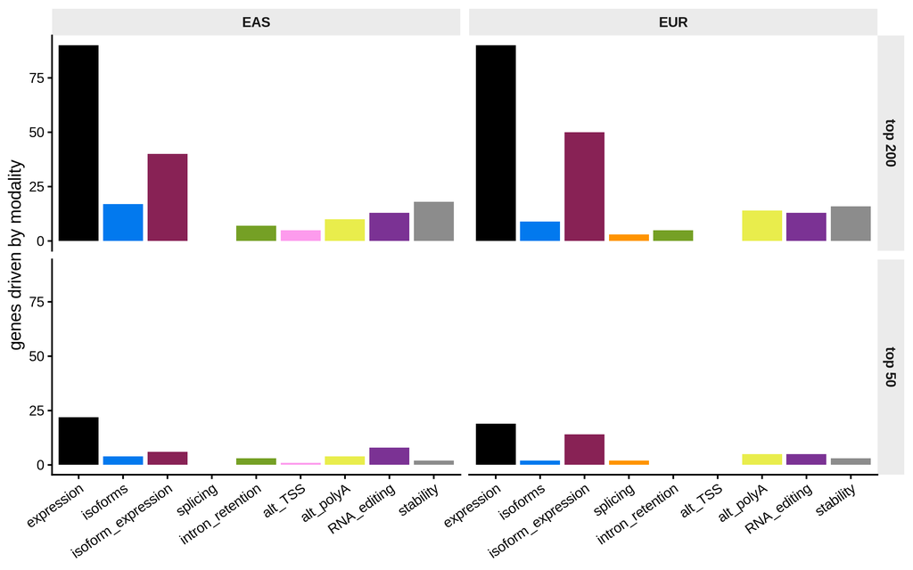

expression drives the largest share of top-ranked genes in EAS (44% of the top 50); expression does so in EUR (38% of the top 50).

### 6.5.1 Within-gene driver breakdown for the top combined genes

EAS top-10 genes: top 5 phenotypes each (ungrouped layer).

| gene_id | gene_symbol | modality | phenotype_id | variant_id | af | slope | pval_beta | qval |
| --- | --- | --- | --- | --- | --- | --- | --- | --- |
| ENSG00000077942 | FBLN1 | isoform_expression | ENSG00000077942.19__HPLRT_ba7f4185a16 | 22:45483551:C:T | 0.556 | 0.695 | 0.000 | 0.000 |
| ENSG00000077942 | FBLN1 | isoform_expression | ENSG00000077942.19__HPLRT_26695ad6d5b | 22:45483551:C:T | 0.556 | 0.488 | 0.000 | 0.000 |
| ENSG00000077942 | FBLN1 | isoform_expression | ENSG00000077942.19__ENST00000262722.11 | 22:45483551:C:T | 0.556 | 0.477 | 0.000 | 0.000 |
| ENSG00000077942 | FBLN1 | isoform_expression | ENSG00000077942.19__HPLRT_10bb8f2808e | 22:45483103:G:A | 0.548 | 0.513 | 0.000 | 0.000 |
| ENSG00000077942 | FBLN1 | isoform_expression | ENSG00000077942.19__HPLRT_c45de125533 | 22:45483103:G:A | 0.548 | 0.393 | 0.000 | 0.000 |
| ENSG00000079739 | PGM1 | isoform_expression | ENSG00000079739.17__ENST00000371084.8 | 1:63613970:T:A | 0.128 | -0.863 | 0.000 | 0.000 |
| ENSG00000079739 | PGM1 | stability | ENSG00000079739.17 | 1:63131604:C:A | 0.016 | 0.447 | 0.663 | 0.677 |
| ENSG00000111671 | SPSB2 | alt_polyA | ENSG00000111671.10__grp_1_downstream_ENST00000524270.6 | 12:6856030:A:G | 0.493 | 0.359 | 0.006 | 0.151 |
| ENSG00000111671 | SPSB2 | alt_polyA | ENSG00000111671.10__grp_1_downstream_ENST00000519357.1 | 12:6856030:A:G | 0.493 | -0.334 | 0.013 | 0.253 |
| ENSG00000111671 | SPSB2 | alt_polyA | ENSG00000111671.10__grp_2_downstream_HPLRT_fc33a693bce | 12:6856030:A:G | 0.493 | 0.346 | 0.014 | 0.262 |
| ENSG00000111671 | SPSB2 | alt_polyA | ENSG00000111671.10__grp_2_downstream_ENST00000519357.1 | 12:7103730:G:A | 0.965 | 0.897 | 0.028 | 0.359 |
| ENSG00000114473 | IQCG | alt_TSS | ENSG00000114473.14__grp_2_upstream_ENST00000478903.5 | 3:197962641:A:G | 0.043 | 1.600 | 0.000 | 0.000 |
| ENSG00000114473 | IQCG | alt_TSS | ENSG00000114473.14__grp_2_upstream_ENST00000455191.5 | 3:197912956:C:G | 0.049 | -0.768 | 0.000 | 0.005 |
| ENSG00000114473 | IQCG | alt_TSS | ENSG00000114473.14__grp_2_upstream_ENST00000265239.11 | 3:197962641:A:G | 0.043 | -0.795 | 0.002 | 0.082 |
| ENSG00000114473 | IQCG | alt_TSS | ENSG00000114473.14__grp_1_upstream_ENST00000265239.11 | 3:197851707:A:G | 0.062 | -0.606 | 0.006 | 0.157 |
| ENSG00000114473 | IQCG | alt_TSS | ENSG00000114473.14__grp_1_upstream_ENST00000455191.5 | 3:197851707:A:G | 0.062 | 0.593 | 0.007 | 0.183 |
| ENSG00000143337 | TOR1AIP1 | isoform_expression | ENSG00000143337.19__ENST00000528443.6 | 1:179878267:T:G | 0.254 | 0.980 | 0.000 | 0.000 |
| ENSG00000143337 | TOR1AIP1 | isoforms | ENSG00000143337.19__ENST00000528443.6 | 1:179855458:T:A | 0.254 | 0.903 | 0.000 | 0.000 |
| ENSG00000143337 | TOR1AIP1 | splicing | ENSG00000143337.19_*chr1_179884769_179889310_clu_2057*+ | 1:180018644:C:A | 0.031 | 0.712 | 0.511 | 0.897 |
| ENSG00000143337 | TOR1AIP1 | splicing | ENSG00000143337.19_*chr1_179884769_179889313_clu_2057*+ | 1:180534943:A:G | 0.013 | -1.054 | 0.535 | 0.902 |

# 7 Functional characterization

*eGene-set functional enrichment, in the style of DevBrain Fig. S4D.*

## 7.1 Functional enrichment (g:Profiler)

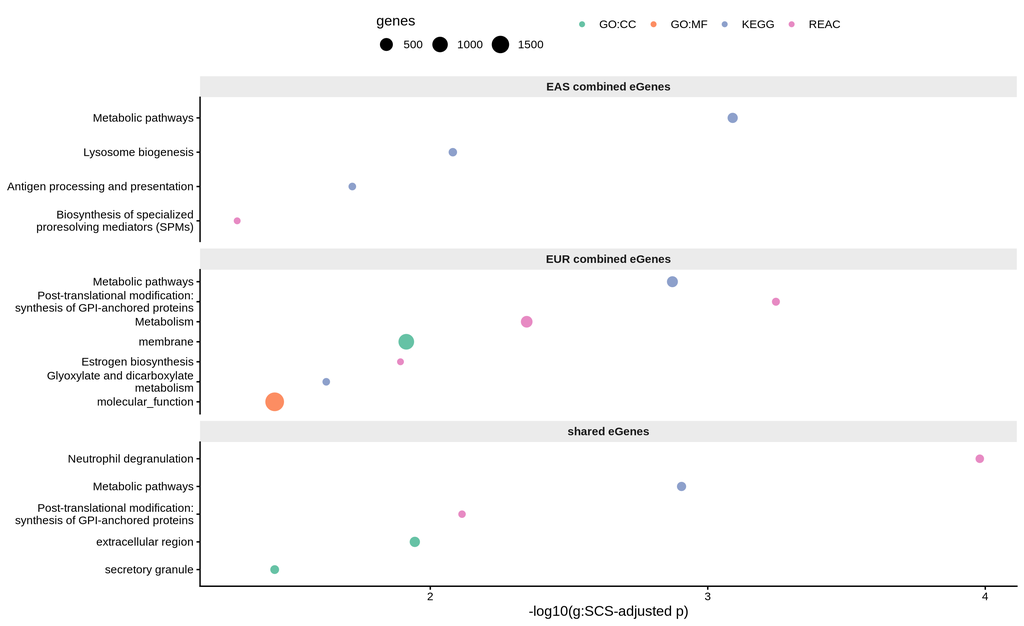

Top 5 enriched terms per eGene set (full tables in tables/enrichment_*.tsv).

| query_set | source | term_id | term_name | p_value | intersection_size |
| --- | --- | --- | --- | --- | --- |
| EAS combined eGenes | KEGG | KEGG:01100 | Metabolic pathways | 0.001 | 157 |
| EAS combined eGenes | KEGG | KEGG:04142 | Lysosome biogenesis | 0.008 | 40 |
| EAS combined eGenes | KEGG | KEGG:04612 | Antigen processing and presentation | 0.019 | 14 |
| EAS combined eGenes | REAC | REAC:R-HSA-9018678 | Biosynthesis of specialized proresolving mediators (SPMs) | 0.050 | 6 |
| EUR combined eGenes | REAC | REAC:R-HSA-163125 | Post-translational modification: synthesis of GPI-anchored proteins | 0.001 | 23 |
| EUR combined eGenes | KEGG | KEGG:01100 | Metabolic pathways | 0.001 | 234 |
| EUR combined eGenes | REAC | REAC:R-HSA-1430728 | Metabolism | 0.004 | 318 |
| EUR combined eGenes | GO:CC | GO:0016020 | membrane | 0.012 | 1044 |
| EUR combined eGenes | REAC | REAC:R-HSA-193144 | Estrogen biosynthesis | 0.013 | 6 |
| shared eGenes | REAC | REAC:R-HSA-6798695 | Neutrophil degranulation | 0.000 | 43 |
| shared eGenes | KEGG | KEGG:01100 | Metabolic pathways | 0.001 | 81 |
| shared eGenes | REAC | REAC:R-HSA-163125 | Post-translational modification: synthesis of GPI-anchored proteins | 0.008 | 11 |
| shared eGenes | GO:CC | GO:0005576 | extracellular region | 0.011 | 164 |
| shared eGenes | GO:CC | GO:0030141 | secretory granule | 0.036 | 56 |

Enrichment is over-representation analysis on the FDR ≤ 5% combined-layer eGene sets (per ancestry, plus shared and ancestry-specific sets) against the **tested-gene universe of the same stratum** — not the whole genome — following the DevBrain xQTL convention; g:SCS is g:Profiler’s native multiple-testing correction. Sets with fewer than 5 genes are skipped (ORA is not meaningful). Full term tables are in `tables/enrichment_*.tsv`.

# 8 Biological interpretation

**The discovery landscape: 7328 FDR ≤ 5% phenotype-level associations** (2707 EAS / 4621 EUR, ungrouped + expression layers) implicating 1667 / 2470 unique genes, with the gene-level combined-layer catalog at **1311 EAS and 2184 EUR eGenes** (n ≈ 280/140, MAF ≥ 0.01 + MAC ≥ 5, genome-wide permutation calibration). Strongest per ancestry: EAS: ENSG00000290199 (expression, grouped layer, q = 2.1e-25, r² ≈ 0.45); EUR: ERAP1 (alt_polyA, ungrouped layer, q = 1.8e-36, r² ≈ 0.45). Hit effect sizes (r² 0.00–0.77) sit in the class the power floor permits. All hits should be treated as candidates: visual QC of phenotype levels by genotype and replication in larger placental cohorts come before functional claims.

Three **characterization** observations:

1. **Modality composition.** expression leads the EAS grouped-eGene breakdown (1099 of 2403); expression leads the EUR grouped-eGene breakdown (1326 of 3879) PANTRY’s central finding was that non-expression modalities carry the largest share of regulatory signal; the driver-modality composition of the catalog (above) tests whether that ordering holds in placenta.
2. **Ancestry sharing.** 580 of 1310 EAS and 2181 EUR combined-layer eGenes are shared (Fisher OR 4.73, p = 7e-129 vs the tested-in-both universe). Shared eGenes are the cross-ancestry replication signal; specific sets are candidates for ancestry-biased regulation.
3. **Functional enrichment.** Top g:Profiler term per set: EAS combined eGenes — Metabolic pathways (KEGG, g:SCS p = 0.00081); EUR combined eGenes — Post-translational modification: synthesis of GPI-anchored proteins (REAC, g:SCS p = 0.00057); shared eGenes — Neutrophil degranulation (REAC, g:SCS p = 1e-04). Full tables in tables/enrichment_*.tsv.

## 8.1 Literature context

**Positive control: the ERAP1/ERAP2 locus (5q15).** The strongest signal shared across ancestries is *ERAP2* — a top-10 combined-layer gene in both strata (EAS #6, q = 9.1×10⁻¹⁹, expression driver; EUR #3, q = 1.3×10⁻²⁸, **isoform-expression** driver) — with *ERAP1* the #1 gene in EUR (q = 2.0×10⁻³⁰, alt_polyA driver). *ERAP2* is a canonical preeclampsia risk locus: fetal-genome variants at *ERAP2* associate with preeclampsia in Australian/Norwegian ([Johnson et al. 2009](https://doi.org/10.1007/s00439-009-0714-x)), Brazilian ([Ferreira et al. 2021](https://doi.org/10.1038/s41598-021-86240-z)), and African American ([Hill et al. 2011](https://doi.org/10.1186/1471-2350-12-64)) cohorts, and ERAP1/ERAP2 are differentially expressed in preeclamptic placentas ([Seamon et al. 2020](https://doi.org/10.3389/fimmu.2020.00396)). The EUR driver being isoform expression is mechanism-consistent: the preeclampsia-associated *ERAP2* variation tags a haplotype under balancing selection whose molecular effect is alternative splicing and nonsense-mediated decay of *ERAP2* transcripts ([Andrés et al. 2010](https://doi.org/10.1371/journal.pgen.1001157); [Raja & Kuiper 2023](https://doi.org/10.1038/s41435-023-00225-8); [Ye et al. 2018](https://doi.org/10.1101/gr.240390.118)) — exactly the phenotype class our isoform-expression layer measures. Recovering this locus, through the expected modality, is direct evidence that the atlas captures disease-relevant placental regulation.

**Top combined-layer genes, per ancestry.** EAS: the top signal is *PGM1* (#1, q = 6.4×10⁻²⁴, expression driver) — placental phosphoglucomutase activity is long established ([Fazi et al. 1990](https://doi.org/10.1080/00327489008050198)) and PGM1 loss disrupts cellular energy homeostasis ([Conte et al. 2023](https://doi.org/10.3390/ijms24098247)), relevant to placental glycogen handling in diabetic pregnancy ([Lafta et al. 2021](https://doi.org/10.28969/ijeir.v10.i2.r3)); followed by an uncharacterized lncRNA (*ENSG00000290199*, #2, q = 3.4×10⁻²²) — a novel candidate with no annotation; *PSCA* (#3, alt_polyA driver) — overexpressed in gestational trophoblastic neoplasia ([Feng et al. 2007](https://doi.org/10.1111/j.1365-2559.2007.02925.x)); *FBLN1* (#4, isoform-expression driver) — fibulin-1 functions in placentation ([Singh et al. 2006](https://doi.org/10.1016/j.placenta.2005.10.009)), placental ECM remodeling in late-onset preeclampsia ([García-Montero et al. 2026](https://doi.org/10.3390/medsci14030364)), and maternal plasma fibulin-1 tracking pregnancy progression ([Orvik et al. 2021](https://doi.org/10.1186/s12884-021-04110-y)); *IQCG* (#5, expression driver) — ciliary/flagellar function with no prior placental association (novel candidate); *THNSL2* (#7, expression driver) — no prior placental association (novel candidate); *RPS28* (#8, expression driver) — small-subunit ribosomal protein with no prior placental association (novel candidate); *SPSB2* (#9, expression driver) — an E3-ligase adaptor targeting iNOS for proteasomal degradation ([Kuang et al. 2010](https://doi.org/10.1083/jcb.200912087); [Li et al. 2021](https://doi.org/10.1016/j.niox.2021.04.004)), placing it in nitric-oxide biology central to placental vascular function; *TOR1AIP1* (#10, isoform-expression driver) — the LAP1 nuclear-envelope protein; biallelic loss causes multisystemic nuclear envelopathy with growth retardation ([Fichtman et al. 2019](https://doi.org/10.1038/s41467-019-08493-7); reviewed in [Mackels et al. 2023](https://doi.org/10.3390/ijms24086911)), with no prior placental association; *CPVL* (#11, expression driver) — a macrophage serine carboxypeptidase ([Mahoney et al. 2001](https://doi.org/10.1006/geno.2000.6484)) with no prior placental association (novel candidate); *MRPL43* (#12, intron-retention driver) — a mitoribosomal protein already known to carry an antagonistic cis-eQTL acting oppositely on transcription and translation ([Han & Lee 2022](https://doi.org/10.1186/s12863-022-01057-7)), and fellow mitoribosomal subunit *MRPL13* drives trophoblast mitochondrial stress in early-onset preeclampsia ([Chen et al. 2026](https://doi.org/10.1093/reprod/xaag016)). EUR: *ERAP1* (#1) and *ERAP2* (#3) above; *ZSCAN9* (#2, expression driver) — KRAB zinc-finger with no prior placental association (novel candidate); *CTNND1* (#4, RNA-editing driver) — p120-catenin is required for trophoblast proliferation and lineage specification at implantation ([Qin et al. 2024](https://doi.org/10.1093/biolre/ioae163)) and sits in the Wnt-regulated invasion program ([Knöfler & Pollheimer 2013](https://doi.org/10.3389/fgene.2013.00190)); *STBD1* (#5, expression driver) — the glycophagy receptor linking glycogen to selective autophagy ([Zhang et al. 2024](https://doi.org/10.1073/pnas.2402817121); [Tang et al. 2023](https://doi.org/10.1002/jcp.31078)), a second glycogen-metabolism hit alongside *PGM1*; *CTSB* (#6, RNA-editing driver) — cathepsin B, whose serum level is elevated in preeclampsia and tracks disease severity ([Kim et al. 2016](https://doi.org/10.1007/s00404-016-4129-3); [Park et al. 2020](https://doi.org/10.1007/s00404-020-05478-6)); *APIP* (#7, stability driver) — an anti-apoptotic Apaf-1 inhibitor protective under hypoxia/ischemia ([Cho et al. 2004](https://doi.org/10.1074/jbc.m405747200)) that is also the methionine-salvage enzyme mtnB ([Mary et al. 2012](https://doi.org/10.1371/journal.pone.0052877)) — a plausible hypoxia-response link to placental biology; *MEAK7* (#8, expression driver) — an mTORC1-associated protein; trophoblast mTOR signaling controls placental nutrient transport and fetal growth ([Shao et al. 2021](https://doi.org/10.1073/pnas.2017092118); [Rosario et al. 2025](https://doi.org/10.1042/cs20243293)); *ARFGAP3* (#9, isoform-expression driver) — COPI vesicle-coat assembly at the Golgi ([Kartberg et al. 2010](https://doi.org/10.1074/jbc.m110.180380)), no prior placental association; *WDR91* (#10, expression driver) — a Rab7 effector in endolysosomal trafficking ([Rapiteanu et al. 2016](https://doi.org/10.1111/tra.12409); [Ma et al. 2024](https://doi.org/10.1016/j.str.2024.09.023)), no prior placental association; *GBP3* (#11, isoform-expression driver) — an interferon-inducible GTPase in cell-autonomous immunity ([Tretina et al. 2019](https://doi.org/10.1084/jem.20182031); [Kirkby et al. 2023](https://doi.org/10.1016/j.tibs.2023.07.002)), no prior placental association; *RBBP4* (#12, RNA-editing driver) — a NuRD-complex histone chaperone essential for preimplantation development ([Miao et al. 2020](https://doi.org/10.1093/biolre/ioaa046)), with NuRD activity gating trophectoderm fate in ES cells ([Latos et al. 2012](https://doi.org/10.1242/bio.2012513)) — a plausible chromatin link to trophoblast lineage control.

**Modality-matched covariates, in line with QTL practice.** Latent-factor covariates are a standard power lever in QTL mapping ([Stegle et al. 2012](https://doi.org/10.1038/nprot.2011.457)), and splicing layers — quantified annotation-free from intron usage ([Li et al. 2017](https://doi.org/10.1038/s41588-017-0004-9)) — have hidden structure that need not track gene expression. The per-modality HCP choice behaved as that practice predicts: EUR splicing was null under expression-derived factors and recovers 423 eGenes at its own modality-matched k*, while the EAS splicing null is flat across the entire k grid, excluding covariate specification as its cause.

Sub-threshold top-ranked genes (tables above) remain prioritization hints only — and the flagged low-carrier rows should be discounted outright.

# 9 Limitations and next steps

1. **Power.** n ≈ 280/140 with a ~12k-gene testing burden detects only r² ≳ 0.10 (EAS) / 0.19 (EUR) effects. Doubling n would roughly halve the detectable r²; matching PANTRY’s n = 445 would bring the floor to ≈ 0.06. Adding the remaining cohorts and the AFR/AMR/SAS strata is the highest-value next step.
2. **EAS splicing is near-null.** The layer yields a handful of FDR ≤ 5% eGenes while EUR splicing — at a higher detection floor — yields 423. The EAS result is robust to HCP count (flat k-grid), so covariate specification is excluded as the cause; the leading candidate is cross-cohort heterogeneity in junction-level quantification (EAS pools four cohorts spanning single- and paired-end protocols). Revisiting splicing quantification harmonization across the EAS cohorts, and adding EAS cohorts, are the targeted next steps.
3. **Technical replicates.** 25 mapped individuals (4 EAS, 21 EUR) have two RNA-seq runs. Phenotype values come from the single ComBat-processed run per individual, while run-level covariates (cell-type fractions, QC metrics) are averaged across the pair — a slight phenotype/covariate misalignment for those individuals. Future runs will collapse replicates at the count level before batch correction so phenotypes and covariates are averaged consistently, with a pre-collapse replicate-concordance QC gate.
4. **Carrier-count propagation.** The MAC ≥ 5 floor predates outlier exclusion, so low-carrier tests persist in some mapping outputs (audit table above). No reported result depends on them; hit lists should post-filter to ma_count ≥ 5, and re-applying the floor after outlier exclusion would remove them at the source.
5. **Ancestry asymmetry.** EUR tests more phenotypes than EAS in every modality (ancestry-specific filtering), so cross-ancestry comparisons are restricted to genes tested in both.
6. **No pooled cross-ancestry inference** was performed. If combined discovery is wanted later, Fisher/Stouffer or an inverse-variance slope meta-analysis are the clean options.
7. **Stepwise secondary signals**: 1,086 units carry a conditionally independent secondary signal (table above).
8. **Fine-mapping is in progress; colocalization is future work.** The phenotype-level discovery set (ungrouped layer + expression) is being fine-mapped jointly across ancestries with SuSHiE (modules 31–34; per-variant PIPs, 95% credible sets, cross-ancestry effect correlations, and functional-annotation enrichment of high-PIP variants) — results are reported separately (`report_finemap`). GWAS colocalization (coloc/eCAVIAR) against placental and pregnancy-outcome GWAS and locus-zoom visual QC of each hit remain the next steps after fine-mapping.
9. **Replication path**: the FDR-significant hits are the priorities for lookup in larger placental resources or a future meta-analysis; visual QC of phenotype levels by genotype is the immediate sanity check for each.

# 10 Reproducibility

- Results: tensorQTL cis mapping (grouped / ungrouped / combined layers, each with stepwise `cis.map_independent` scans), MAF ≥ 0.01 + MAC ≥ 5 at the genotype intersection, ±1 Mb window, **Storey q-values** on pval_beta via the R `qvalue` package (singularity-R bridge). Covariates: as described (first-5 PCs + HCP_1–k* + sex/GA/cell types; maternal fraction excluded before correlation pruning; no cap). Genotype PCs: cohort-only plink2 PCA on LD-pruned variants.
- Fine-mapping: SuSHiE joint cross-ancestry fine-mapping of the FDR-significant phenotype-level discovery set (ungrouped layer; expression from the primary scan), with fastVEP/cCRE/open-chromatin enrichment of high-PIP variants (scripts 31–34).
- Pipeline scripts: this repository (`05_qtl_mapping/`, scripts 19–35 + `compute_qvalues.R`; genotype pooling in `01_genotype_imputation/`).
- Report extras: targeted cross-ancestry/cross-modality lookups, showcase locus scans, lead-variant annotations, and gnomAD constraint tables (`05_qtl_mapping/35_extract_report_extras.py`), staged into the archive under `data/extras/` by `make_report_archive.sh`; report panels that use them render only when the corresponding file is present.
- Report code: `report_placenta_xqtl.Rmd` + `xqtl_report_functions.R`; figures in `figures/`, tables in `tables/`.
- Gene symbols: `gene_map.tsv` regenerated in full from the normalized GTF (config `normalized_gtf`) by `make_report_archive.sh` at archive time — covers every tested gene, version-stripped IDs.